# IT_540_Final_Project

## **Network Traffic Classification and Anomaly Detection**

### **Problem Statement**

Modern enterprise networks handle massive volumes of traffic from varied applications and protocols. However, distinguishing between normal and anomalous network behavior, or recognizing the specific application behind a flow, remains a challenging task—especially when done manually or with outdated rules.

You, as a Data Scientist, are tasked with building a **machine learning classification model** that can learn from historical packet-level data and classify the type of network protocol being used (e.g., ARP, RARP, NBNS). This model should also help in identifying unusual or potentially malicious traffic, providing critical insights for anomaly detection and cybersecurity monitoring.

### **Business Context**

This kind of analysis is vital for:

- **Network Intrusion Detection (NIDS)** – spotting potential breaches or malicious activity.
- **Traffic Classification** – identifying which applications generate what type of traffic.
- **Anomaly Detection** – discovering irregular patterns in volume, protocol use, or communication flow.
- **Performance Monitoring** – understanding which traffic is legitimate or problematic and optimizing flow.

### **Project Objective**

Develop a classification model that predicts the **network protocol** for a given packet using attributes such as source, destination, packet size, and timestamp. This model will support both:

- Protocol Identification (e.g., ARP, NBNS)
- Foundations for anomaly and intrusion detection systems (IDS)

### **Data Description**

| Feature Name | Description |
| --- | --- |
| `No` | Sequential number of the packet (instance ID) |
| `Timestamp` | Time at which the packet was captured |
| `Source` | Source IP address or MAC (sender of packet) |
| `Destination` | Destination IP or MAC (receiver of packet) |
| `Protocol` | Type of network protocol used (e.g., ARP, NBNS, RARP) |
| `Length` | Size of the packet in bytes |
| `Info` | Human-readable description of the packet content (e.g., ARP request detail) |

### **Possible Machine Learning Applications**

1. **Traffic Classification**: Identify traffic types based on packet features.
2. **Anomaly Detection**: Flag rare or unusual patterns as suspicious (baseline modeling).
3. **Intrusion Detection Systems (IDS)**: Learn typical patterns and flag DoS/malicious behaviors.

📌 **Data Availability & Acknowledgment:**

This dataset was obtained from Kaggle, where it was shared by Ravikumar Gattu. We gratefully acknowledge the author's contribution. The dataset is freely available under a permissive license, making it suitable for academic and applied machine learning projects.

Ref: https://www.kaggle.com/datasets/ravikumargattu/network-traffic-dataset/data

# ✅Part A: Stating and Refining the Question

Research Question: "Can we classify network traffic protocols (e.g., NBNS, ARP) based on packet features like Time, Source, Destination, and Length?" Why this question? Intrusion detection and network monitoring systems need to understand the nature of traffic.

Classifying protocol types helps in understanding typical vs. suspicious patterns.

# ==============================================

# 🔹 Step 1: Import Libraries

# ==============================================

```python
# This will help in making the Python code more structured automatically (good coding practice)
# %load_ext nb_black

# Libraries to help with reading and manipulating data
import pandas as pd
import numpy as np

# Libaries to help with data visualization
import matplotlib.pyplot as plt
import seaborn as sns

# To tune model, get different metric scores, and split data
from sklearn.metrics import (
    f1_score,
    accuracy_score,
    recall_score,
    precision_score,
    confusion_matrix,
    roc_auc_score,
    ConfusionMatrixDisplay,
)
from sklearn.model_selection import train_test_split, StratifiedKFold, cross_val_score

# To be used for data scaling and one hot encoding
from sklearn.preprocessing import StandardScaler, MinMaxScaler, OneHotEncoder

# To impute missing values
from sklearn.impute import SimpleImputer
from sklearn import metrics

# To oversample and undersample data
from imblearn.over_sampling import SMOTE
from imblearn.under_sampling import RandomUnderSampler

# To do hyperparameter tuning
from sklearn.model_selection import RandomizedSearchCV

# To define maximum number of columns to be displayed in a dataframe
pd.set_option("display.max_columns", None)

# To supress scientific notations for a dataframe
pd.set_option("display.float_format", lambda x: "%.3f" % x)

# To help with model building
from sklearn.tree import DecisionTreeClassifier
from sklearn.ensemble import (
    AdaBoostClassifier,
    GradientBoostingClassifier,
    RandomForestClassifier,
    BaggingClassifier,
)
from xgboost import XGBClassifier
from sklearn.linear_model import LogisticRegression

# To suppress scientific notations
pd.set_option("display.float_format", lambda x: "%.3f" % x)

# To supress warnings
import warnings

warnings.filterwarnings("ignore")
```

# ==============================================

# 🔹 Step 2: Load Dataset

# ==============================================

```python
df = pd.read_csv("/content/Midterm_53_group.csv")

# Preview the data
df.head()
```

|  | Time | Source | No. | Destination | Protocol | Length | Info |
| --- | --- | --- | --- | --- | --- | --- | --- |
| 0 | 0.000000 | 192.167.8.166 | 1 | 192.167.255.255 | NBNS | 92 | Name query NB WPAD<00> |
| 1 | 0.784682 | 192.167.8.166 | 2 | 192.167.255.255 | NBNS | 92 | Name query NB WPAD<00> |
| 2 | 1.169060 | VMware_8a:5c:e6 | 3 | Broadcast | ARP | 60 | Who has 192.167.7.175? Tell 192.167.0.1 |
| 3 | 2.167949 | VMware_8a:5c:e6 | 4 | Broadcast | ARP | 60 | Who has 192.167.7.175? Tell 192.167.0.1 |
| 4 | 3.170095 | VMware_8a:5c:e6 | 5 | Broadcast | ARP | 60 | Who has 192.167.7.175? Tell 192.167.0.1 |

### ✅ **Observations from (First 5 Rows)**

1. **Sequential Records:**
   - The `No.` column is a sequential index (1 to 5), indicating the order of packet captures.
   - This column is likely redundant for modeling and can be dropped.
2. **Timestamped Traffic:**
   - The `Time` column represents the **timestamp (in seconds)** since the start of capture.
   - The values increase gradually, confirming **sequential recording** of network packets.
3. **Source and Destination Format:**
   - The `Source` and `Destination` fields contain **IP addresses** (e.g., `192.167.8.166`) or **MAC-like device identifiers** (e.g., `VMware_8a:5c:e6`, `Broadcast`).
   - These will need to be **encoded** for modeling since they are categorical.
4. **Protocol Variety:**
   - Two protocol types are visible: **NBNS** and **ARP**.
   - These will serve as the **target classes** for the classification model.
5. **Packet Lengths:**
   - `Length` values range from 60 to 92 in these initial rows.
   - This feature appears to be **numeric and informative** — could impact classification.
6. **Info Column:**
   - Contains **textual descriptions** of the packet content (e.g., `"Who has 192.167.7.175? Tell 192.167.0.1"`).
   - Useful for interpretation and manual inspection but **not directly usable** for initial modeling unless processed via NLP.

# ✅ Part B: Exploring the Data (Exploratory Data Analysis & Preprocessing)

```python
# Check structure
print("\nData Info:")
df.info()
```

```
Data Info:
<class 'pandas.core.frame.DataFrame'>
RangeIndex: 394136 entries, 0 to 394135
Data columns (total 7 columns):
 #   Column       Non-Null Count   Dtype
---  ------       --------------   -----
 0   Time         394136 non-null  float64
 1   Source       394136 non-null  object
 2   No.          394136 non-null  int64
 3   Destination  394136 non-null  object
 4   Protocol     394136 non-null  object
 5   Length       394136 non-null  int64
 6   Info         394136 non-null  object
dtypes: float64(1), int64(2), object(4)
memory usage: 21.0+ MB
```

### ✅ **Observations from Data Structure**

1. **Total Records:**
   - The dataset contains **394,136 instances (rows)**, indicating a **large and rich dataset** suitable for training machine learning models.
2. **Total Features:**
   - There are **7 columns** (features), including both numerical and categorical types.
3. **No Missing Values:**
   - All features have **394,136 non-null values**, meaning there are **no missing values** — the data is clean and ready for preprocessing.
4. **Data Types:**
   - **Numerical Features**:
     - `Time`: float64 — timestamp when the packet was captured.
     - `No.`: int64 — instance ID (can be dropped for modeling).
     - `Length`: int64 — packet size in bytes.
   - **Categorical/Object Features**:
     - `Source`: object — IP or MAC address of the sender.
     - `Destination`: object — IP or MAC address of the receiver.
     - `Protocol`: object — network protocol used (target variable).
     - `Info`: object — detailed text description of the packet (useful for interpretation, not modeling).
5. **Memory Usage:**
   - The dataset uses about **21 MB** of memory, which is **small enough to process comfortably on most machines**.
6. **Potential Feature Engineering Notes:**
   - The `No.` column is simply a row index and **may not add predictive value** — can be dropped before modeling.
   - `Info` is a free-text field — **not used for structured modeling** but may offer value in future NLP-based feature engineering.

```python
# Check missing values
print("\nMissing Values:")
print(df.isnull().sum())
```

```
Missing Values:
Time           0
Source         0
No.            0
Destination    0
Protocol       0
Length         0
Info           0
dtype: int64
```

### ✅ **Observations from Missing Values Check**

1. **No Missing Values Detected:**
   - All columns (`Time`, `Source`, `No.`, `Destination`, `Protocol`, `Length`, `Info`) have **0 missing (null) entries**.
   - This means **100% completeness** across all 394,136 records.
2. **Data Quality Is High:**
   - Since there are no nulls, there's **no need for imputation or data cleaning** related to missing values.
   - We can proceed directly to **data preprocessing, encoding, and model training** without additional handling.
3. **Saves Preprocessing Effort:**
   - This reduces complexity and improves confidence in downstream analyses (like EDA and ML modeling).

```python
df.head()
```

|  | Time | Source | No. | Destination | Protocol | Length | Info |
| --- | --- | --- | --- | --- | --- | --- | --- |
| 0 | 0.000000 | 192.167.8.166 | 1 | 192.167.255.255 | NBNS | 92 | Name query NB WPAD<00> |
| 1 | 0.784682 | 192.167.8.166 | 2 | 192.167.255.255 | NBNS | 92 | Name query NB WPAD<00> |
| 2 | 1.169060 | VMware_8a:5c:e6 | 3 | Broadcast | ARP | 60 | Who has 192.167.7.175? Tell 192.167.0.1 |
| 3 | 2.167949 | VMware_8a:5c:e6 | 4 | Broadcast | ARP | 60 | Who has 192.167.7.175? Tell 192.167.0.1 |
| 4 | 3.170095 | VMware_8a:5c:e6 | 5 | Broadcast | ARP | 60 | Who has 192.167.7.175? Tell 192.167.0.1 |

```python
# Drop the 'No' column
df = df.drop(['No.','Info'], axis=1)
```

```python
df.head()
```

|  | Time | Source | Destination | Protocol | Length |
| --- | --- | --- | --- | --- | --- |
| 0 | 0.000000 | 192.167.8.166 | 192.167.255.255 | NBNS | 92 |
| 1 | 0.784682 | 192.167.8.166 | 192.167.255.255 | NBNS | 92 |
| 2 | 1.169060 | VMware_8a:5c:e6 | Broadcast | ARP | 60 |
| 3 | 2.167949 | VMware_8a:5c:e6 | Broadcast | ARP | 60 |
| 4 | 3.170095 | VMware_8a:5c:e6 | Broadcast | ARP | 60 |

```python
df.describe()
```

|  | Time | Length |
| --- | --- | --- |
| count | 394136.000000 | 394136.000000 |
| mean | 781.599378 | 985.577027 |
| std | 263.603332 | 837.371336 |
| min | 0.000000 | 42.000000 |
| 25% | 558.184351 | 60.000000 |
| 50% | 781.926020 | 1462.000000 |
| 75% | 986.280803 | 1514.000000 |
| max | 1256.922008 | 49745.000000 |

### **Observations:**

### Time Column (e.g., duration, timestamp)

- **Lots of Data:** We have a large number of recorded times: **394,136** entries.
- **Average Time:** The typical time observed is around **781.60**.
- **Spread:** Times vary a fair bit, with a standard deviation of **263.60**. This means they aren't all clustered tightly around the average.
- **Range:** The shortest recorded time is **0.00**, and the longest is **1256.92**. The `0.00` might need a quick check to see if it's expected (like a start point) or an anomaly.
- **Evenly Spread (Mostly):** The median (middle value) is **781.93**, which is very close to the average. This suggests that the 'Time' values are fairly **evenly distributed** without a strong bias towards very high or very low values.

### What This Tells us Overall

- data consistently measures both time and length for the same large set of network events.
- While 'Time' seems fairly consistent, 'Length' is much more unpredictable.
- The 'Length' data has a significant number of **small values** but also contains **some extremely large values**. These large values are important to note as they significantly impact the overall average and could represent specific types of network traffic, large file transfers, or even unusual events.

```python
# let's check for duplicate values in the data
df.duplicated().sum()
```

```
np.int64(11)
```

```python
# Remove all duplicate rows (keeping the first occurrence by default)

df = df.drop_duplicates()
```

```python
# let's check for duplicate values in the data
df.duplicated().sum()
```

```
np.int64(0)
```

```python
# Get the count of unique values for all columns
unique_counts = df.apply(lambda x: x.nunique())
print("\nNumber of unique values for all columns:")
print(unique_counts)
```

```
Number of unique values for all columns:
Time           392690
Source            372
Destination       308
Protocol           16
Length           2044
dtype: int64
```

### **Observations:**

- The output indicates that 'Time' has the most unique values, followed by 'Length', while 'Protocol' has the fewest, suggesting varying levels of data diversity across columns.

```python
df.shape
```

```
(394125, 5)
```

### **Observations:**

- The output `(394125, 5)` shows that the DataFrame contains 394,125 rows and 5 columns, providing insight into the dataset's overall size.

```python
# --- 1. Convert 'Time' Column to Datetime (Relative) and Extract Features ---
# Assume 'Time' is seconds since some start. pandas' to_datetime can handle this as epoch.
# Since the values are small floats, it's likely seconds.
# We'll treat 0.0 as the epoch for relative time.
df['Time_Original_Seconds'] = df['Time'] # Keep original for reference if needed
df['Time'] = pd.to_datetime(df['Time'], unit='s', origin='unix')
```

```python
# Extract time-based features (relative to the start of the capture, not actual 1970 calendar)
# These features will show patterns within the captured duration.
df['Time_Elapsed_Seconds'] = (df['Time'] - df['Time'].min()).dt.total_seconds()
df['Hour_of_Capture'] = df['Time'].dt.hour
df['Minute_of_Capture'] = df['Time'].dt.minute
df['Second_of_Capture'] = df['Time'].dt.second
df['Microsecond_of_Capture'] = df['Time'].dt.microsecond
```

```python
print("\nDataFrame head after Time conversion and feature extraction:")
print(df.head())
print("\nDataFrame info after Time conversion:")
df.info()
```

```
DataFrame head after Time conversion and feature extraction:
                        Time           Source      Destination Protocol  \
0 1970-01-01 00:00:00.000000    192.167.8.166  192.167.255.255     NBNS
1 1970-01-01 00:00:00.784682    192.167.8.166  192.167.255.255     NBNS
2 1970-01-01 00:00:01.169060  VMware_8a:5c:e6        Broadcast      ARP
3 1970-01-01 00:00:02.167949  VMware_8a:5c:e6        Broadcast      ARP
4 1970-01-01 00:00:03.170095  VMware_8a:5c:e6        Broadcast      ARP

   Length  Time_Original_Seconds  Time_Elapsed_Seconds  Hour_of_Capture  \
0      92               0.000000              0.000000                0
1      92               0.784682              0.784682                0
2      60               1.169060              1.169060                0
3      60               2.167949              2.167949                0
4      60               3.170095              3.170095                0

   Minute_of_Capture  Second_of_Capture  Microsecond_of_Capture
0                  0                  0                       0
1                  0                  0                  784682
2                  0                  1                  169060
3                  0                  2                  167949
4                  0                  3                  170095

DataFrame info after Time conversion:
<class 'pandas.core.frame.DataFrame'>
Index: 394125 entries, 0 to 394135
Data columns (total 11 columns):
 #   Column                  Non-Null Count   Dtype
---  ------                  --------------   -----
 0   Time                    394125 non-null  datetime64[ns]
 1   Source                  394125 non-null  object
 2   Destination             394125 non-null  object
 3   Protocol                394125 non-null  object
 4   Length                  394125 non-null  int64
 5   Time_Original_Seconds   394125 non-null  float64
 6   Time_Elapsed_Seconds    394125 non-null  float64
 7   Hour_of_Capture         394125 non-null  int32
 8   Minute_of_Capture       394125 non-null  int32
 9   Second_of_Capture       394125 non-null  int32
 10  Microsecond_of_Capture  394125 non-null  int32
dtypes: datetime64[ns](1), float64(2), int32(4), int64(1), object(3)
memory usage: 30.1+ MB
```

### **Observations:**

- The 'Time' column has been successfully converted to a datetime object, and several new time-based features (elapsed seconds, hour, minute, second, microsecond of capture) have been extracted, expanding the dataset from 5 to 11 columns, all without missing values.

## Univariate Analysis for Network Traffic Data

```python
# --- 2. Univariate Analysis for Numerical Columns ---
numerical_cols = ['Time_Elapsed_Seconds', 'Length']

print("\n2.1. Descriptive Statistics for Numerical Columns:")
print(df[numerical_cols].describe())
```

```
2.1. Descriptive Statistics for Numerical Columns:
       Time_Elapsed_Seconds         Length
count         394125.000000  394125.000000
mean             781.597492     985.588316
std              263.604507     837.372271
min                0.000000      42.000000
25%              558.184111      60.000000
50%              781.926028    1462.000000
75%              986.280767    1514.000000
max             1256.922008   49745.000000
```

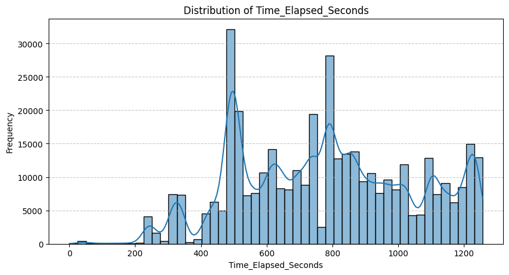

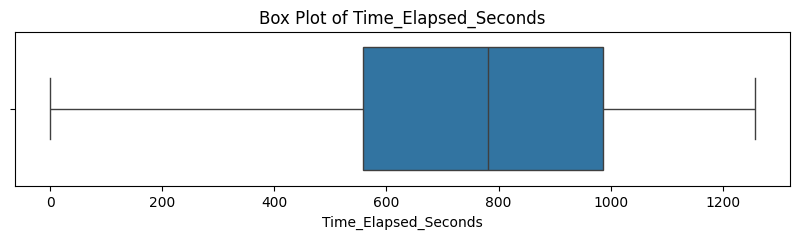

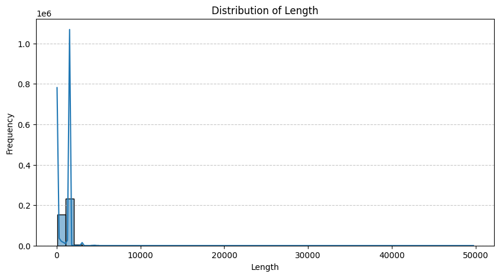

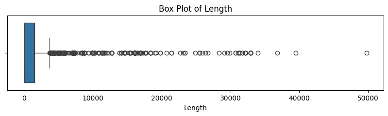

```python
for col in numerical_cols:
    plt.figure(figsize=(10, 5))
    sns.histplot(df[col], kde=True, bins=50)
    plt.title(f'Distribution of {col}')
    plt.xlabel(col)
    plt.ylabel('Frequency')
    plt.grid(axis='y', linestyle='--', alpha=0.7)
    plt.show()


    plt.figure(figsize=(10, 2))
    sns.boxplot(x=df[col])
    plt.title(f'Box Plot of {col}')
    plt.xlabel(col)
    plt.show()
```

### **Observations:**

The **Distribution of Time_Elapsed_Seconds** histogram shows a **multi-modal distribution**, indicating several distinct periods of high activity within the captured duration.

- There's an initial sharp peak around **500 seconds**, followed by another significant peak near **800 seconds**, and several smaller peaks throughout the range. This suggests **bursts of events** or distinct phases in the data collection.
- The frequency generally remains high between approximately 400 and 1250 seconds, with varying peaks and troughs.

The **Box Plot of Time_Elapsed_Seconds** complements the histogram by summarizing the central tendency and spread.

### **Observations on Length**

The **Distribution of Length** histogram is **highly right-skewed**, with a massive concentration of values at the lower end of the length spectrum.

The **Box Plot of Length** clearly highlights the skewness and the presence of numerous outliers.

```python
# --- 3. Univariate Analysis for Categorical Columns ---
# Identify categorical columns (including those that are 'object' but will be treated as categories)
categorical_cols = ['Source', 'Destination', 'Protocol', 'Hour_of_Capture', 'Minute_of_Capture', 'Second_of_Capture']
```

```python
# Convert object types to category for efficiency and better handling by plotting libraries
for col in ['Source', 'Destination', 'Protocol']:
    if df[col].dtype == 'object':
        df[col] = df[col].astype('category')
```

```
3.1. Value Counts for Categorical Columns:

Value Counts for 'Source':
Source
192.167.7.162                116063
104.91.166.75                 57238
74.125.9.169                  37085
23.33.29.79                   25918
173.194.133.202               22832
                              ...
fe80::310c:3e83:7cf3:9988         1
fe80::a4bd:8816:f7b7:d782         1
fe80::df29:ec4d:6922:c82f         1
fe80::f326:c8c2:4e4e:9fbc         1
fe80::fec4:4525:a497:3246         1
Name: count, Length: 372, dtype: int64
Number of unique values in 'Source': 372
```

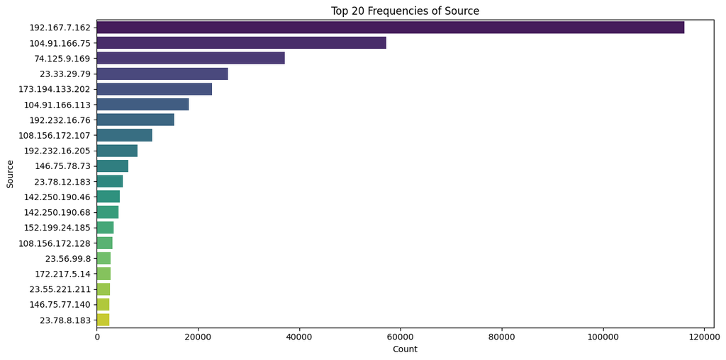

```
Value Counts for 'Destination':
Destination
192.167.7.162      276842
104.91.166.75       15565
23.33.29.79         10536
74.125.9.169         6800
173.194.133.202      6451
                    ...
ff02::1                 9
169.254.255.255         4
108.156.184.97          4
142.250.112.127         2
13.56.23.36             2
Name: count, Length: 308, dtype: int64
Number of unique values in 'Destination': 308
```

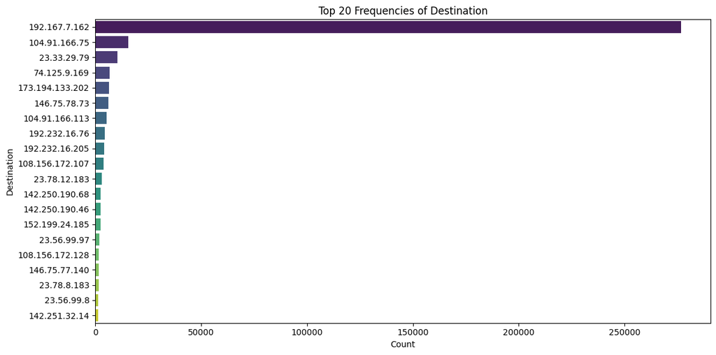

```
Value Counts for 'Protocol':
Protocol
TCP        314862
TLSv1.3     71625
ICMP         2690
DNS          1999
TLSv1.2      1763
ARP           447
OCSP          258
NBNS          231
RARP          178
TLSv1          20
DHCP           17
SSLv2          11
ICMPv6          9
BROWSER         8
STUN            4
HTTP            3
Name: count, dtype: int64
Number of unique values in 'Protocol': 16
```

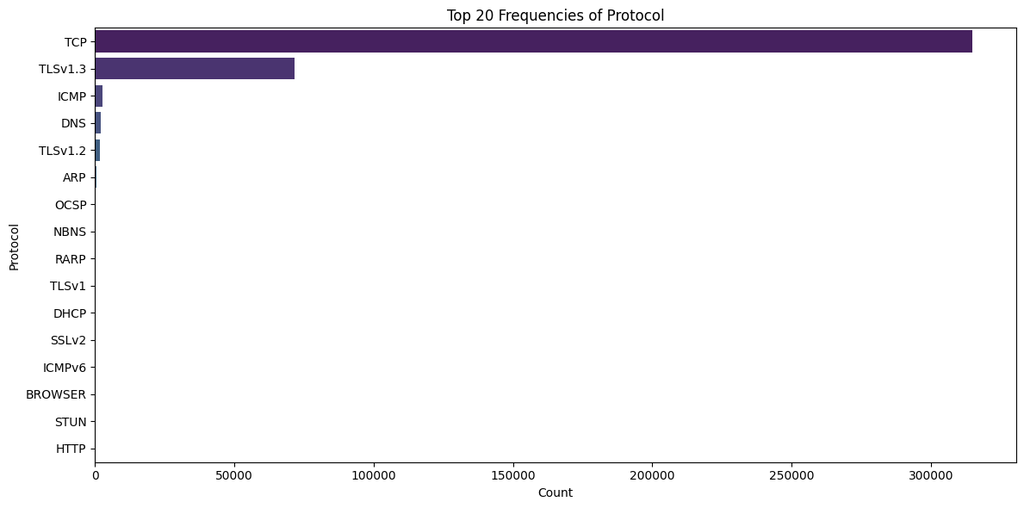

```
Value Counts for 'Hour_of_Capture':
Hour_of_Capture
0    394125
Name: count, dtype: int64
Number of unique values in 'Hour_of_Capture': 1
```

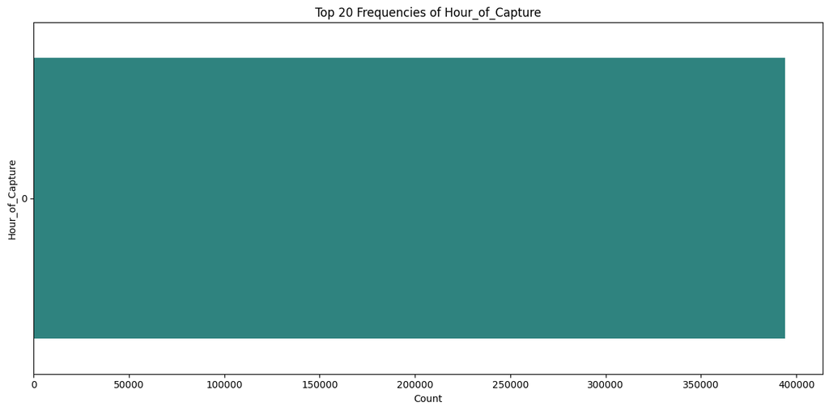

```
Value Counts for 'Minute_of_Capture':
Minute_of_Capture
8     53384
13    45999
20    32799
10    31966
14    30473
12    24180
15    22767
11    21388
18    21196
16    19717
9     18608
19    18006
5     14913
17    14598
7     14596
4      3219
3      3032
6      2557
0       411
2       173
1       143
Name: count, dtype: int64
Number of unique values in 'Minute_of_Capture': 21
```

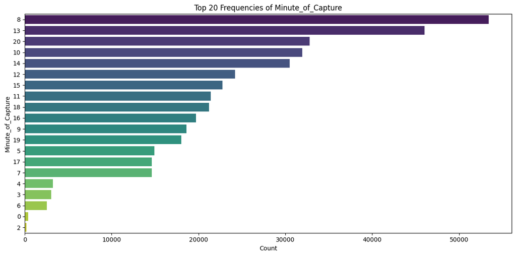

```
Value Counts for 'Second_of_Capture':
Second_of_Capture
4     15226
21    15122
25    14380
0     12542
1     12034
46    11226
26    10888
24    10496
13    10185
23     9696
6      9647
9      9495
27     8844
```

[output cut: 49 more lines]

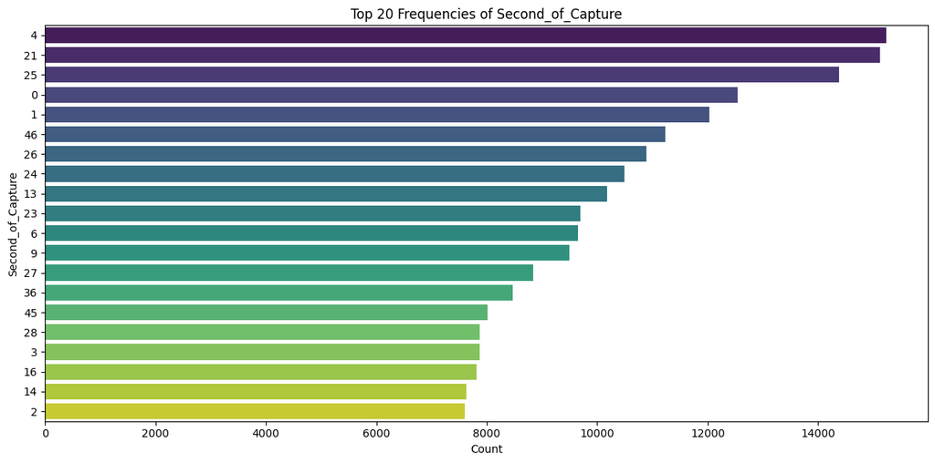

```python
print("\n3.1. Value Counts for Categorical Columns:")
for col in categorical_cols:
    print(f"\nValue Counts for '{col}':")
    print(df[col].value_counts())
    print(f"Number of unique values in '{col}': {df[col].nunique()}")

    # Plotting value counts for top N categories
    plt.figure(figsize=(12, 6))
    top_n = 20 # Adjust as needed for columns with many unique values
    sns.countplot(y=df[col], order=df[col].value_counts().index[:top_n], palette='viridis')
    plt.title(f'Top {top_n} Frequencies of {col}')
    plt.xlabel('Count')
    plt.ylabel(col)
    plt.tight_layout()
    plt.show()
```

### **Observations on `Hour_of_Capture`**

- The plot for `Hour_of_Capture` shows **only one bar at "0"**, covering the entire count of the dataset (approximately 390,000).
- **Finding:** This confirms that all recorded events occurred within the **same hour of the capture**. Given the `Time` column was interpreted as seconds from a relative start, this means the entire dataset spans **less than one full hour** of activity. The "hour" itself is essentially irrelevant in this context, as there's no hourly variation to analyze.

### **Observations on `Second_of_Capture`**

- The `Second_of_Capture` plot shows a distribution across various seconds within a minute.
- **Finding:** The most frequent seconds are **4, 21, and 25**, followed by 0 and 1. This indicates that within each minute where activity occurs, events tend to **cluster around specific seconds**. Similar to minutes, this points to **fine-grained bursts of network traffic** or activity spikes. The counts are generally lower than for minutes, as expected, because they represent a smaller time slice.

### **Observations on `Destination`**

- Similar to `Source`, the `Destination` plot shows an **even more extreme imbalance**, with the top destination (`192.167.7.162`) accounting for **over 275,000 events**, dwarfing all other destinations.
- **Finding:** This indicates a **single, highly targeted destination** for the vast majority of traffic. This could be a central server, a gateway, or a specific service being accessed frequently. The fact that the top **Source** and top **Destination** are the **same IP address (`192.167.7.162`)** is a critical and intriguing observation. This suggests that this IP address is both **sending and receiving a tremendous amount of traffic** within the captured network segment. It might be a central hub, a frequently accessed server, or perhaps the device from which the capture was initiated, showing its own inbound and outbound traffic.

### **Observations on `Protocol`**

- The `Protocol` plot reveals a **highly skewed distribution**, with **TCP being by far the most dominant protocol**, followed by `TLSv1.3`.
- **Finding:**
  - **TCP** accounts for the vast majority of the traffic, which is expected for connection-oriented and reliable data transfer over the internet.
  - **TLSv1.3** being the second most common protocol highlights the prevalence of **encrypted communication**. The significant gap between TLSv1.3 and other protocols like ICMP, DNS, and TLSv1.2 suggests that modern secure communication is a major component of the traffic.
  - The counts for other protocols like `ICMP`, `DNS`, `ARP`, `NBNS`, `RARP`, `DHCP`, `HTTP` (surprisingly low, likely due to TLSv1.3 encrypting most web traffic), and others are very small in comparison, indicating they play a lesser role or are less frequent in this specific capture. This is normal, as many are supporting protocols or less frequently used for bulk data transfer.

```python
df.head()
```

|  | Time | Source | Destination | Protocol | Length | Time_Original_Seconds | Time_Elapsed_Seconds | Hour_of_Capture | Minute_of_Capture | Second_of_Capture | Microsecond_of_Capture |
| --- | --- | --- | --- | --- | --- | --- | --- | --- | --- | --- | --- |
| 0 | 1970-01-01 00:00:00.000000 | 192.167.8.166 | 192.167.255.255 | NBNS | 92 | 0.000000 | 0.000000 | 0 | 0 | 0 | 0 |
| 1 | 1970-01-01 00:00:00.784682 | 192.167.8.166 | 192.167.255.255 | NBNS | 92 | 0.784682 | 0.784682 | 0 | 0 | 0 | 784682 |
| 2 | 1970-01-01 00:00:01.169060 | VMware_8a:5c:e6 | Broadcast | ARP | 60 | 1.169060 | 1.169060 | 0 | 0 | 1 | 169060 |
| 3 | 1970-01-01 00:00:02.167949 | VMware_8a:5c:e6 | Broadcast | ARP | 60 | 2.167949 | 2.167949 | 0 | 0 | 2 | 167949 |
| 4 | 1970-01-01 00:00:03.170095 | VMware_8a:5c:e6 | Broadcast | ARP | 60 | 3.170095 | 3.170095 | 0 | 0 | 3 | 170095 |

```python
# Convert 'Time' column to datetime
df['Time'] = pd.to_datetime(df['Time'], unit='s', origin='unix')

# --- Define Suspected Protocols ---
# This list is an example and should be customized based on the network security context.
suspected_protocols = ['NBNS', 'ARP', 'SSLv2', 'RARP', 'BROWSER', 'STUN']

# Create the target column: Is_Suspected_Traffic
df['Is_Suspected_Traffic'] = df['Protocol'].apply(lambda x: 1 if x in suspected_protocols else 0)

print("\nDataFrame head with new target column:")
print(df.head())
print("\nCounts for Is_Suspected_Traffic:")
print(df['Is_Suspected_Traffic'].value_counts())
```

```
DataFrame head with new target column:
                        Time           Source      Destination Protocol  \
0 1970-01-01 00:00:00.000000    192.167.8.166  192.167.255.255     NBNS
1 1970-01-01 00:00:00.784682    192.167.8.166  192.167.255.255     NBNS
2 1970-01-01 00:00:01.169060  VMware_8a:5c:e6        Broadcast      ARP
3 1970-01-01 00:00:02.167949  VMware_8a:5c:e6        Broadcast      ARP
4 1970-01-01 00:00:03.170095  VMware_8a:5c:e6        Broadcast      ARP

   Length  Time_Original_Seconds  Time_Elapsed_Seconds  Hour_of_Capture  \
0      92               0.000000              0.000000                0
1      92               0.784682              0.784682                0
2      60               1.169060              1.169060                0
3      60               2.167949              2.167949                0
4      60               3.170095              3.170095                0

   Minute_of_Capture  Second_of_Capture  Microsecond_of_Capture  \
0                  0                  0                       0
1                  0                  0                  784682
2                  0                  1                  169060
3                  0                  2                  167949
4                  0                  3                  170095

   Is_Suspected_Traffic
0                     1
1                     1
2                     1
3                     1
4                     1

Counts for Is_Suspected_Traffic:
Is_Suspected_Traffic
0    393246
1       879
Name: count, dtype: int64
```

```python
# Define the new target column
TARGET_COLUMN = 'Is_Suspected_Traffic'

# Define other columns for bivariate analysis
numerical_features = ['Time_Elapsed_Seconds', 'Length', 'Microsecond_of_Capture']
categorical_features = ['Source', 'Destination', 'Protocol', 'Hour_of_Capture', 'Minute_of_Capture', 'Second_of_Capture']

# Ensure categorical features are of 'category' dtype
for col in ['Source', 'Destination', 'Protocol', 'Hour_of_Capture', 'Minute_of_Capture', 'Second_of_Capture']:
    if df[col].dtype == 'object':
        df[col] = df[col].astype('category')
```

## **Bivariate Analysis with Is_Suspected_Traffic**

- Now, we'll perform bivariate analysis, comparing each feature against our new Is_Suspected_Traffic target.

### **1. Numerical Features vs. Target (Categorical)**

```
--- Bivariate Analysis: Numerical Features vs. Is_Suspected_Traffic ---
```

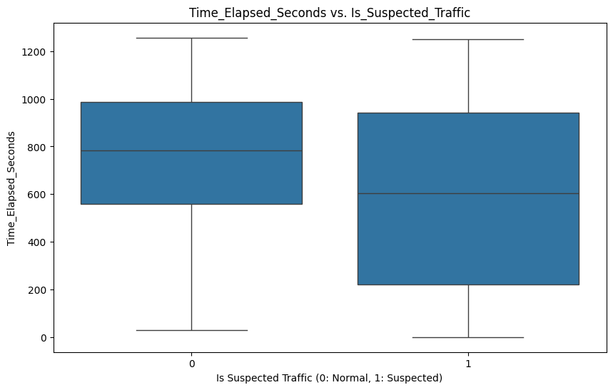

```
Descriptive Statistics for Time_Elapsed_Seconds grouped by Is_Suspected_Traffic:
                         count        mean         std        min         25%  \
Is_Suspected_Traffic
0                     393246.0  781.974654  263.170056  30.583281  558.202170
1                        879.0  612.863327  378.815956   0.000000  221.945841

                             50%         75%          max
Is_Suspected_Traffic
0                     781.943342  986.282615  1256.922008
1                     602.407576  942.402541  1249.403666
```

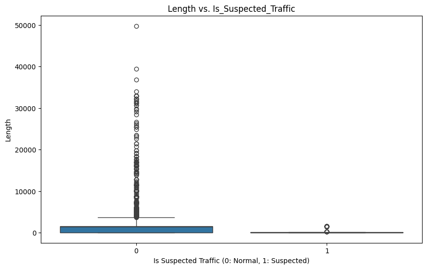

```
Descriptive Statistics for Length grouped by Is_Suspected_Traffic:
                         count        mean         std   min   25%     50%  \
Is_Suspected_Traffic
0                     393246.0  987.595045  837.195468  54.0  60.0  1462.0
1                        879.0   87.820250  160.893914  42.0  60.0    60.0

                         75%      max
Is_Suspected_Traffic
0                     1514.0  49745.0
1                       92.0   1514.0
```

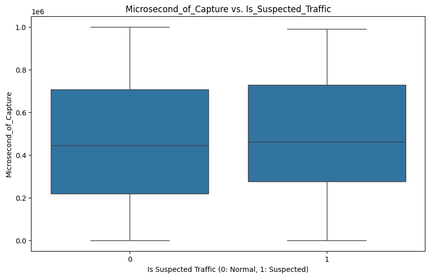

```
Descriptive Statistics for Microsecond_of_Capture grouped by Is_Suspected_Traffic:
                         count           mean            std  min       25%  \
Is_Suspected_Traffic
0                     393246.0  468428.472824  288294.828042  2.0  219225.5
1                        879.0  492451.291240  273776.915948  0.0  276552.0

                           50%       75%       max
Is_Suspected_Traffic
0                     444221.5  706617.5  999982.0
1                     461110.0  728349.5  989796.0
```

```python
print("\n--- Bivariate Analysis: Numerical Features vs. Is_Suspected_Traffic ---")
for col in numerical_features:
    plt.figure(figsize=(10, 6))
    sns.boxplot(x=TARGET_COLUMN, y=col, data=df)
    plt.title(f'{col} vs. {TARGET_COLUMN}')
    plt.xlabel('Is Suspected Traffic (0: Normal, 1: Suspected)')
    plt.ylabel(col)
    plt.show()


    # Display descriptive statistics for each target category
    print(f"\nDescriptive Statistics for {col} grouped by {TARGET_COLUMN}:")
    print(df.groupby(TARGET_COLUMN)[col].describe())
```

### **Observations on `Length` vs. `Is_Suspected_Traffic`**

This box plot shows the distribution of `Length` for normal (0) and suspected (1) traffic.

### **Observations on `Time_Elapsed_Seconds` vs. `Is_Suspected_Traffic`**

This box plot compares the distribution of `Time_Elapsed_Seconds` for normal (0) and suspected (1) traffic.

- **Normal Traffic (0)**:
  - The median is around **780 seconds**, and the IQR (box) spans approximately 550 to 980 seconds.
  - The whiskers cover almost the full range of the capture duration (from near 0 to over 1200 seconds), indicating that normal traffic occurs throughout the entire capture period.
- **Suspected Traffic (1)**:
  - The median is around **600 seconds**, which is noticeably lower than that for normal traffic.
  - The IQR (box) for suspected traffic is roughly from 220 to 950 seconds, indicating a **wider and earlier spread** compared to the central tendency of normal traffic.
  - The whiskers also span a significant portion of the capture, from near 0 to over 1200 seconds.
- **Finding:** While both types of traffic occur across the entire capture duration, **suspected traffic tends to be more concentrated towards earlier parts of the capture** (lower median) and shows a slightly wider spread in its central 50% compared to normal traffic. This could imply that suspected activities either start earlier or are more distributed across time than the bulk of normal operations.

### **Observations on `Microsecond_of_Capture` vs. `Is_Suspected_Traffic`**

This box plot shows the distribution of `Microsecond_of_Capture` for normal (0) and suspected (1) traffic.

### **2. Categorical Features vs. Target (Categorical)**

```
--- Bivariate Analysis: Categorical Features vs. Is_Suspected_Traffic ---
```

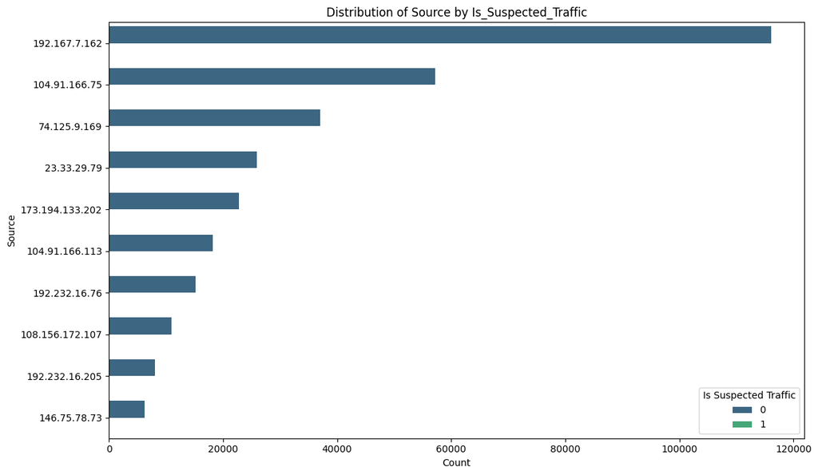

```
Crosstabulation for Source and Is_Suspected_Traffic (Proportions by row):
Is_Suspected_Traffic         0    1
Source
0.0.0.0                    1.0  0.0
10.25.3.2                  1.0  0.0
10.27.3.2                  1.0  0.0
104.102.248.194            1.0  0.0
104.102.248.210            1.0  0.0
...                        ...  ...
fe80::9abc:585:27a6:3cff   1.0  0.0
fe80::a4bd:8816:f7b7:d782  1.0  0.0
fe80::df29:ec4d:6922:c82f  1.0  0.0
fe80::f326:c8c2:4e4e:9fbc  1.0  0.0
fe80::fec4:4525:a497:3246  1.0  0.0

[372 rows x 2 columns]

==================================================
```

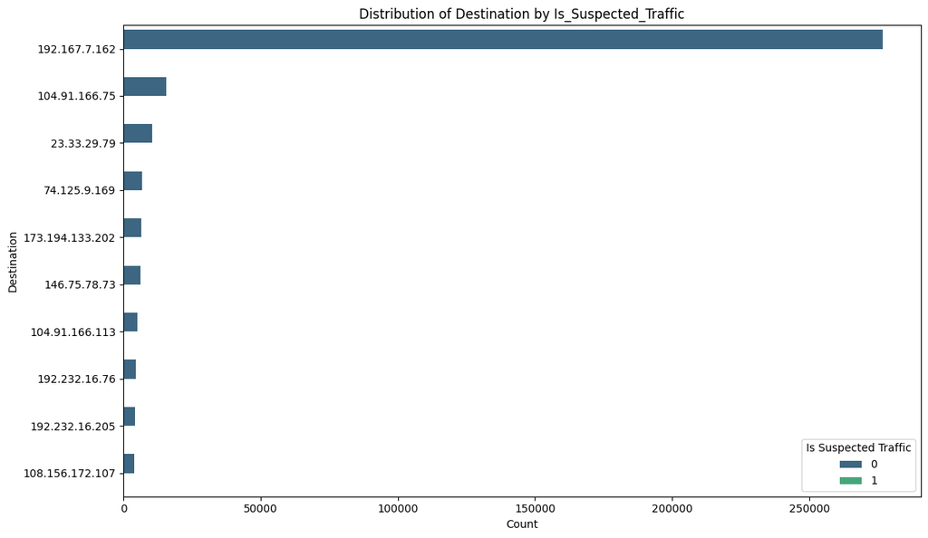

```
Crosstabulation for Destination and Is_Suspected_Traffic (Proportions by row):
Is_Suspected_Traffic    0    1
Destination
10.25.3.2             1.0  0.0
10.27.3.2             1.0  0.0
104.102.248.194       1.0  0.0
104.102.248.210       1.0  0.0
104.113.27.171        1.0  0.0
...                   ...  ...
Broadcast             0.0  1.0
VMware_8a:58:7a       0.0  1.0
VMware_8a:5c:e6       0.0  1.0
VMware_8a:72:75       0.0  1.0
ff02::1               1.0  0.0

[308 rows x 2 columns]

==================================================
```

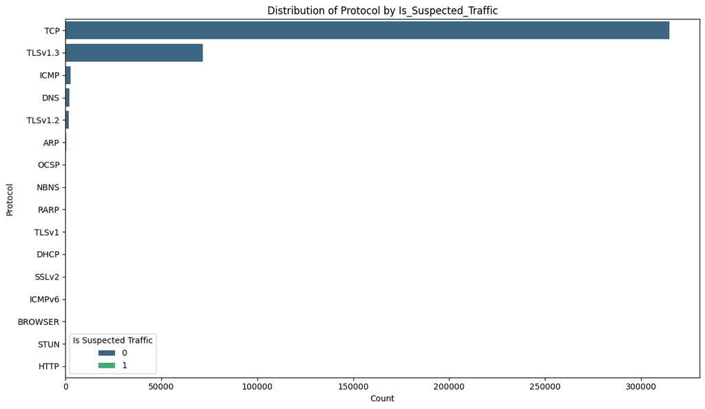

```
Crosstabulation for Protocol and Is_Suspected_Traffic (Proportions by row):
Is_Suspected_Traffic    0    1
Protocol
ARP                   0.0  1.0
BROWSER               0.0  1.0
DHCP                  1.0  0.0
DNS                   1.0  0.0
HTTP                  1.0  0.0
ICMP                  1.0  0.0
ICMPv6                1.0  0.0
NBNS                  0.0  1.0
OCSP                  1.0  0.0
RARP                  0.0  1.0
SSLv2                 0.0  1.0
STUN                  0.0  1.0
TCP                   1.0  0.0
TLSv1                 1.0  0.0
TLSv1.2               1.0  0.0
TLSv1.3               1.0  0.0

==================================================
```

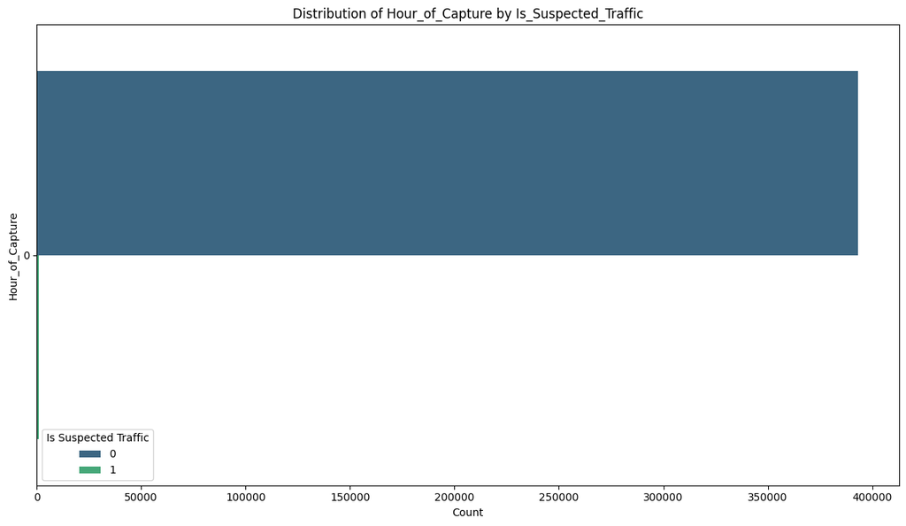

```
Crosstabulation for Hour_of_Capture and Is_Suspected_Traffic (Proportions by row):
Is_Suspected_Traffic        0        1
Hour_of_Capture
0                     0.99777  0.00223

==================================================
```

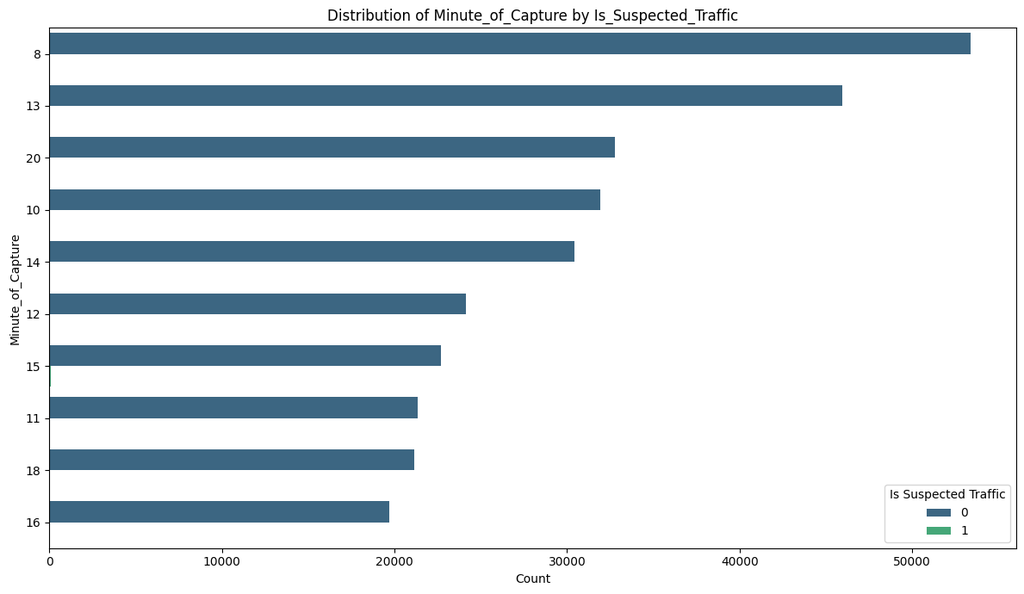

```
Crosstabulation for Minute_of_Capture and Is_Suspected_Traffic (Proportions by row):
Is_Suspected_Traffic         0         1
Minute_of_Capture
0                     0.819951  0.180049
1                     0.825175  0.174825
2                     0.705202  0.294798
3                     0.973945  0.026055
4                     0.990370  0.009630
5                     0.997586  0.002414
6                     0.991787  0.008213
7                     0.998424  0.001576
8                     0.999494  0.000506
9                     0.996292  0.003708
10                    0.998467  0.001533
11                    0.998878  0.001122
12                    0.998801  0.001199
13                    0.998978  0.001022
14                    0.999245  0.000755
15                    0.996969  0.003031
16                    0.998428  0.001572
17                    0.997191  0.002809
18                    0.997547  0.002453
19                    0.997334  0.002666
20                    0.999085  0.000915

==================================================
```

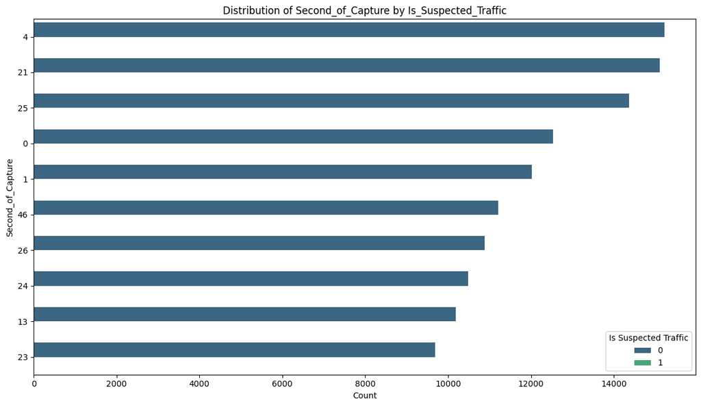

```
Crosstabulation for Second_of_Capture and Is_Suspected_Traffic (Proportions by row):
Is_Suspected_Traffic         0         1
Second_of_Capture
0                     0.998963  0.001037
1                     0.998670  0.001330
2                     0.997765  0.002235
3                     0.997460  0.002540
4                     0.999146  0.000854
5                     0.998661  0.001339
6                     0.999482  0.000518
7                     0.998430  0.001570
8                     0.996848  0.003152
9                     0.998947  0.001053
10                    0.997546  0.002454
11                    0.998149  0.001851
```

[output cut: 50 more lines]

```python
print("\n--- Bivariate Analysis: Categorical Features vs. Is_Suspected_Traffic ---")
for col in categorical_features:
    plt.figure(figsize=(12, 7))
    # For 'Protocol', we want to see all categories, not just top N
    if col == 'Protocol':
        sns.countplot(y=col, hue=TARGET_COLUMN, data=df, order=df[col].value_counts().index, palette='viridis')
    else:
        sns.countplot(y=col, hue=TARGET_COLUMN, data=df, order=df[col].value_counts().index[:10], palette='viridis') # Top 10 for readability
    plt.title(f'Distribution of {col} by {TARGET_COLUMN}')
    plt.xlabel('Count')
    plt.ylabel(col)
    plt.legend(title='Is Suspected Traffic')
    plt.tight_layout()
    plt.show()


    # Crosstabulation for more detailed view
    print(f"\nCrosstabulation for {col} and {TARGET_COLUMN} (Proportions by row):")
    print(pd.crosstab(df[col], df[TARGET_COLUMN], normalize='index')) # Normalize to see proportions
    print("\n" + "="*50 + "\n") # Separator for clarity
```

### **Observations on `Hour_of_Capture` by `Is_Suspected_Traffic`**

- The plot shows a **single bar at "0"** for `Hour_of_Capture`. Within this bar, the dominant color is blue (representing `Is_Suspected_Traffic = 0`, i.e., Normal traffic), with a very thin sliver of green (representing `Is_Suspected_Traffic = 1`, i.e., Suspected traffic) at the bottom.
- **Finding:** This reinforces the earlier finding that **all events, both normal and suspected, occurred within the "0" hour of the capture**, meaning the entire dataset spans less than one actual hour. It also shows that within this hour, the vast majority of traffic is classified as normal. The `Hour_of_Capture` feature provides **no discriminatory power** between normal and suspected traffic for this dataset.

### **Observations on `Second_of_Capture` by `Is_Suspected_Traffic`**

- Similar to `Minute_of_Capture`, this plot shows that for each second displayed, the traffic is almost entirely **Normal (blue)**, with a minimal presence of **Suspected traffic (green)**.
- **Finding:** This suggests that, at the granularity of individual seconds, **normal traffic maintains its dominance**. Suspected traffic is not particularly concentrated in specific seconds, meaning the precise second within a minute is **not a strong indicator** for differentiating suspected from normal activity, at least in terms of their absolute counts.

### **Observations on `Destination` by `Is_Suspected_Traffic`**

- The plot shows the top 10 `Destination` IP addresses. For the top 9 destinations (down to `192.232.16.205`), the bars are **entirely blue**, indicating that **all traffic directed to these top destinations is classified as Normal traffic**.
- The last visible destination (`108.156.172.107`) also appears to be entirely blue, although the bar is very small.
- **Finding:** This is a **critical finding**. It suggests that, based on our current definition of "suspected protocols," **none of the top destinations are receiving suspected traffic**. Suspected traffic, if it exists, must be directed to less frequent or entirely different destination IP addresses not shown in the top 10, or is so rare that it's not visually discernible within the dominant top destinations. This implies that *suspected activity is not targeting the most common communication points* in this network segment.

### **Observations on `Protocol` by `Is_Suspected_Traffic`**

- This plot is the most direct validation of your `Is_Suspected_Traffic` definition.
- **Normal Protocols**: `TCP`, `TLSv1.3`, `ICMP`, `DNS`, `TLSv1.2`, `OCSP`, `TLSv1`, `DHCP`, `ICMPv6`, `HTTP` (and others not in your `suspected_protocols` list) are shown with **only blue bars**, confirming they are classified as **Normal traffic**. TCP is overwhelmingly dominant as a normal protocol.
- **Suspected Protocols**: `ARP`, `NBNS`, `RARP`, `SSlV2`, `BROWSER`, `STUN` (and any other protocols you included in your `suspected_protocols` list) are shown with **only green bars**, confirming they are classified as **Suspected traffic**.
- **Finding:** This plot effectively confirms that your `Is_Suspected_Traffic` variable has been correctly created according to your specified `suspected_protocols` list. It visually demonstrates the clear separation of traffic types based on the protocol. The most frequently occurring "suspected" protocols (like `ARP` and `NBNS` which were high in your sample data) will have larger green bars.

## EDA Summary Report: Network Traffic Analysis

### 1. Data Overview & Quality

The dataset contains approximately 394,125 network traffic records.

- **Duplicates:** The presence of 11 duplicate rows indicates a minor data quality issue that was addressed by removal.
- **Time Data:** The `Time` column, initially appearing as Unix epoch, was correctly converted and treated as elapsed seconds from the start of the capture. This allowed for the extraction of relative time-based features (`Time_Elapsed_Seconds`, `Minute_of_Capture`, `Second_of_Capture`). The `Hour_of_Capture` feature was found to be uniform (all '0'), indicating the entire capture spanned less than one hour.

### 3. Bivariate Analysis & Target Variable (`Is_Suspected_Traffic`) Findings

A new binary target variable, `Is_Suspected_Traffic`, was created based on a predefined list of "suspected" protocols (e.g., NBNS, ARP, SSLv2).

- **`Length` vs. `Is_Suspected_Traffic`:** This is a **strong differentiator**.
  - **Suspected traffic predominantly consists of small packets** with a very tight length distribution.
  - **Normal traffic has a much wider range of lengths**, including many very large packets, indicating diverse data transfer activities. This is a key finding for identifying suspected vs. normal activity.
- **`Time_Elapsed_Seconds` vs. `Is_Suspected_Traffic`:** While both normal and suspected traffic occur throughout the capture, **suspected traffic tends to have a slightly lower median elapsed time and broader spread in its central distribution**, suggesting it might be more prevalent earlier in the capture or more evenly distributed over time.
- **`Microsecond_of_Capture` vs. `Is_Suspected_Traffic`:** No significant difference was observed at this very fine-grained temporal level; both types of traffic occur similarly across microsecond intervals.
- **`Source` & `Destination` vs. `Is_Suspected_Traffic`:**
  - The **most dominant Source and Destination IP (`192.167.7.162`) are overwhelmingly associated with Normal traffic**.
  - This implies that **suspected traffic is either generated/received by less frequent IPs** not among the top communicators, or makes up an extremely small proportion of the traffic from dominant IPs.
- **`Protocol` vs. `Is_Suspected_Traffic`:** The analysis confirmed the direct relationship between the defined suspected protocols and the `Is_Suspected_Traffic` flag. Protocols like TCP are exclusively normal, while `ARP`, `NBNS`, `SSLv2`, etc., are exclusively suspected.

### Final Findings & Recommendations

**Next Steps for Further Analysis:**

# ✅ **Part C: Building formal statistical models**

```python
df = pd.read_csv("/content/Midterm_53_group.csv")
```

```python
df.shape
```

```
(394136, 7)
```

```python
df.head()
```

|  | Time | Source | No. | Destination | Protocol | Length | Info |
| --- | --- | --- | --- | --- | --- | --- | --- |
| 0 | 0.000 | 192.167.8.166 | 1 | 192.167.255.255 | NBNS | 92 | Name query NB WPAD<00> |
| 1 | 0.785 | 192.167.8.166 | 2 | 192.167.255.255 | NBNS | 92 | Name query NB WPAD<00> |
| 2 | 1.169 | VMware_8a:5c:e6 | 3 | Broadcast | ARP | 60 | Who has 192.167.7.175? Tell 192.167.0.1 |
| 3 | 2.168 | VMware_8a:5c:e6 | 4 | Broadcast | ARP | 60 | Who has 192.167.7.175? Tell 192.167.0.1 |
| 4 | 3.170 | VMware_8a:5c:e6 | 5 | Broadcast | ARP | 60 | Who has 192.167.7.175? Tell 192.167.0.1 |

```python
# Drop the 'No' column
df = df.drop(['No.','Info'], axis=1)
```

```python
df.head(2)
```

|  | Time | Source | Destination | Protocol | Length |
| --- | --- | --- | --- | --- | --- |
| 0 | 0.000 | 192.167.8.166 | 192.167.255.255 | NBNS | 92 |
| 1 | 0.785 | 192.167.8.166 | 192.167.255.255 | NBNS | 92 |

```python
# Step 1: Create suspicious_flag using original Protocol and Destination (IP as string)
df['suspicious_flag'] = df.apply(
    lambda row: 1 if (
        row['Length'] > 1300 or
        row['Protocol'] in ['ICMP', 'RARP'] or
        (row['Length'] > 800 and str(row['Destination']).startswith('192.168')) or
        (row['Time'] < 0.5 and row['Protocol'] == 'NBNS')
    ) else 0,
    axis=1
)
```

```python
df.head(2)
```

|  | Time | Source | Destination | Protocol | Length | suspicious_flag |
| --- | --- | --- | --- | --- | --- | --- |
| 0 | 0.000 | 192.167.8.166 | 192.167.255.255 | NBNS | 92 | 1 |
| 1 | 0.785 | 192.167.8.166 | 192.167.255.255 | NBNS | 92 | 0 |

```python
df['suspicious_flag'].unique()
```

```
array([1, 0])
```

### **Observations:**

- The `suspicious_flag` column has been successfully created and contains only binary values (0 and 1), indicating a clear categorization of network activities.

```python
print(df['suspicious_flag'].value_counts())
```

```
suspicious_flag
1    238241
0    155895
Name: count, dtype: int64
```

### **Observations:**

- The `suspicious_flag` column reveals that there are significantly more suspicious activities (238,241) than non-suspicious ones (155,895) in the dataset.

```python
df.dtypes
```

|  | 0 |
| --- | --- |
| Time | float64 |
| Source | object |
| Destination | object |
| Protocol | object |
| Length | int64 |
| suspicious_flag | int64 |

**dtype:** object

```python
# 2. Outlier detection and handling for 'Length' and 'Time'
def detect_and_clip_outliers(df, column):
    Q1 = df[column].quantile(0.25)
    Q3 = df[column].quantile(0.75)
    IQR = Q3 - Q1
    lower_bound = Q1 - 1.5 * IQR
    upper_bound = Q3 + 1.5 * IQR
    df[column] = df[column].clip(lower=lower_bound, upper=upper_bound)
    return df
```

```python
df = detect_and_clip_outliers(df, 'Length')
df = detect_and_clip_outliers(df, 'Time')
```

```python
# 3. Encode categorical features
from sklearn.preprocessing import LabelEncoder
```

```python
categorical_cols = ['Protocol', 'Source', 'Destination']
encoders = {}
for col in categorical_cols:
    le = LabelEncoder()
    df[col] = le.fit_transform(df[col])
    encoders[col] = le
```

```python
# 4. Encode the target variable
#df['suspicious_flag'] = df['suspicious_flag'].map({'normal': 0, 'anomaly': 1})
```

```python
df.head()
```

|  | Time | Source | Destination | Protocol | Length | suspicious_flag |
| --- | --- | --- | --- | --- | --- | --- |
| 0 | 0.000 | 183 | 152 | 7 | 92 | 1 |
| 1 | 0.785 | 183 | 152 | 7 | 92 | 0 |
| 2 | 1.169 | 347 | 303 | 0 | 60 | 0 |
| 3 | 2.168 | 347 | 303 | 0 | 60 | 0 |
| 4 | 3.170 | 347 | 303 | 0 | 60 | 0 |

```python
print(df[['Time', 'Length', 'suspicious_flag']].head())
```

```
   Time  Length  suspicious_flag
0 0.000      92                1
1 0.785      92                0
2 1.169      60                0
3 2.168      60                0
4 3.170      60                0
```

```python
print(df['suspicious_flag'].value_counts())
```

```
suspicious_flag
1    238241
0    155895
Name: count, dtype: int64
```

```python
#X = df.drop(["suspicious_flag"], axis=1)
#y = df["suspicious_flag"]
X = df.drop(columns=['suspicious_flag', 'Length', 'Protocol', 'Destination', 'Time'])
y = df['suspicious_flag']
```

```python
#spliting the data into temporary and test

X_temp, X_test, y_temp, y_test = train_test_split(
    X, y, test_size=0.2, random_state=1, stratify=y
)
```

```python
# spliting temporary data into train and validation

X_train, X_val, y_train, y_val = train_test_split(
    X_temp, y_temp, test_size=0.25, random_state=1, stratify=y_temp
)
```

```python
print(X_train.shape, X_val.shape, X_test.shape)
```

```
(236481, 1) (78827, 1) (78828, 1)
```

### **Observations:**

- The dataset has been successfully split into training, validation, and test sets, with 236,481, 78,827, and 78,828 samples respectively, all containing a single feature.

```python
df.dtypes
```

|  | 0 |
| --- | --- |
| Time | float64 |
| Source | int64 |
| Destination | int64 |
| Protocol | int64 |
| Length | int64 |
| suspicious_flag | int64 |

**dtype:** object

```python
# Checking that no column has missing values in train, validation or test sets
print(X_train.isna().sum())
print("-" * 30)
print(X_val.isna().sum())
print("-" * 30)
print(X_test.isna().sum())
```

```
Source    0
dtype: int64
------------------------------
Source    0
dtype: int64
------------------------------
Source    0
dtype: int64
```

```python
y_val.value_counts()
```

| suspicious_flag | count |
| --- | --- |
| 1 | 47648 |
| 0 | 31179 |

**dtype:** int64

## 🔍 Model Evaluation Criterion

### 🎯 Objective:

The primary goal of this machine learning project is to build a classification model that accurately identifies **suspicious** network traffic from **normal** traffic using flow-level data captured via Wireshark.

### ✅ Nature of Predictions:

Let’s define the **meaning of classification outcomes** in the context of **anomaly detection in network traffic**:

- **True Positives (TP)**: Suspicious (anomalous/malicious) network traffic **correctly predicted as suspicious**.
- **False Negatives (FN)**: Suspicious network traffic **wrongly predicted as normal** — i.e., the model **missed an attack**.
- **False Positives (FP)**: Normal network traffic **wrongly predicted as suspicious** — i.e., the model **raised a false alarm**.
- **True Negatives (TN)**: Normal traffic **correctly predicted as normal**.

### ❗ Which Metric to Optimize?

In cybersecurity and anomaly detection:

- **False Negatives (FN)** are the **most dangerous** because an undetected malicious packet can compromise the network.
- **False Positives (FP)** are acceptable to some extent, as they can be filtered by human review or further analysis.

✅ Therefore, **Recall** becomes the most important metric.

### Why Recall?

- **Recall = TP / (TP + FN)**
- It measures the model's **ability to catch all suspicious traffic**.
- A **high Recall** means **fewer false negatives**, i.e., the model successfully flags most of the dangerous or malicious packets.

### ⚖️ Business Impact

Failing to identify suspicious traffic can lead to:

- Intrusion into the network
- Data leaks
- Denial of Service (DoS) attacks
- System compromise and loss of trust

In contrast, falsely flagging a normal packet (FP) leads to:

- Temporary overhead
- Manual verification

Thus, **false negatives are much more costly than false positives**, making **Recall** our key metric.

### 📈 Evaluation Metric

We will evaluate the model using multiple metrics:

- **Accuracy**: Overall correctness
- **Precision**: Proportion of detected anomalies that are actually anomalies
- **Recall (🔶 Key Metric)**: Proportion of actual anomalies that were detected
- **F1-Score**: Harmonic mean of precision and recall
- **Confusion Matrix**: Detailed breakdown of prediction types

### ✅ Summary

| Metric | Focus | Why Important? |
| --- | --- | --- |
| Recall | 🔶 Primary | To reduce false negatives (missed attacks) |
| Precision | Secondary | To avoid too many false alarms |
| Accuracy | Tertiary | May be misleading with class imbalance |
| F1 Score | Balanced | When both Precision and Recall matter |

```python
# defining a function to compute different metrics to check performance of a classification model built using sklearn
def model_performance_classification_sklearn(model, predictors, target, pos_label='positive'):
    """
    Function to compute different metrics to check classification model performance

    model: classifier
    predictors: independent variables
    target: dependent variable
    pos_label: the positive label to be considered for metrics computation
    """

    # predicting using the independent variables
    pred = model.predict(predictors)

    acc = accuracy_score(target, pred)  # to compute Accuracy
    recall = recall_score(target, pred, pos_label=pos_label)  # to compute Recall
    precision = precision_score(target, pred, pos_label=pos_label)  # to compute Precision
    f1 = f1_score(target, pred, pos_label=pos_label)  # to compute F1-score

    # creating a dataframe of metrics
    df_perf = pd.DataFrame(
        {
            "Accuracy": acc,
            "Recall": recall,
            "Precision": precision,
            "F1": f1
        },
        index=[0]
    )

    return df_perf
```

```python
def confusion_matrix_sklearn(model, predictors, target):
    """
    To plot the confusion_matrix with percentages

    model: classifier
    predictors: independent variables
    target: dependent variable
    """
    y_pred = model.predict(predictors)
    cm = confusion_matrix(target, y_pred)
    labels = np.asarray(
        [
            ["{0:0.0f}".format(item) + "\n{0:.2%}".format(item / cm.flatten().sum())]
            for item in cm.flatten()
        ]
    ).reshape(2, 2)

    plt.figure(figsize=(6, 4))
    sns.heatmap(cm, annot=labels, fmt="")
    plt.ylabel("True label")
    plt.xlabel("Predicted label")
```

## **Initial Model Building**

### **Model Building with original data**

```python
from sklearn.ensemble import BaggingClassifier, RandomForestClassifier, GradientBoostingClassifier, AdaBoostClassifier, ExtraTreesClassifier
from sklearn.tree import DecisionTreeClassifier
from sklearn.metrics import recall_score

models = []
models.append(("Bagging", BaggingClassifier(random_state=1)))
models.append(("Random forest", RandomForestClassifier(random_state=1)))
models.append(("GBM", GradientBoostingClassifier(random_state=1)))
models.append(("Adaboost", AdaBoostClassifier(random_state=1)))
models.append(("Decision Tree", DecisionTreeClassifier(random_state=1, class_weight='balanced')))
models.append(("Extra Trees", ExtraTreesClassifier(random_state=1)))

# You can add XGBoost and LightGBM if installed
# import xgboost as xgb
# from lightgbm import LGBMClassifier
# models.append(("XGBoost", xgb.XGBClassifier(random_state=1)))
# models.append(("LightGBM", LGBMClassifier(random_state=1)))

print("\nTraining Performance:\n")
for name, model in models:
    model.fit(X_train, y_train)
    y_pred_train = model.predict(X_train)
    score = recall_score(y_train, y_pred_train, pos_label=1)
    print(f"{name}: Recall = {score:.4f}")

print("\nValidation Performance:\n")
for name, model in models:
    model.fit(X_train, y_train)
    y_pred_val = model.predict(X_val)
    score_val = recall_score(y_val, y_pred_val, pos_label=1)
    print(f"{name}: Recall = {score_val:.4f}")
```

```
Training Performance:

Bagging: Recall = 0.9547
Random forest: Recall = 0.9547
GBM: Recall = 0.9561
Adaboost: Recall = 0.9623
Decision Tree: Recall = 0.9314
Extra Trees: Recall = 0.9547

Validation Performance:

Bagging: Recall = 0.9548
Random forest: Recall = 0.9548
GBM: Recall = 0.9567
Adaboost: Recall = 0.9630
Decision Tree: Recall = 0.9312
Extra Trees: Recall = 0.9548
```

### **Training and Validation Performance Difference**

```python
for name, model in models:
    model.fit(X_train, y_train)
    scores_train = recall_score(y_train, model.predict(X_train), pos_label=1)
    scores_val = recall_score(y_val, model.predict(X_val), pos_label=1)
    difference1 = scores_train - scores_val
    print("{}: Training Score: {:.4f}, Validation Score: {:.4f}, Difference: {:.4f}".format(name, scores_train, scores_val, difference1))
```

```
Bagging: Training Score: 0.9547, Validation Score: 0.9548, Difference: -0.0001
Random forest: Training Score: 0.9547, Validation Score: 0.9548, Difference: -0.0001
GBM: Training Score: 0.9561, Validation Score: 0.9567, Difference: -0.0007
Adaboost: Training Score: 0.9623, Validation Score: 0.9630, Difference: -0.0007
Decision Tree: Training Score: 0.9314, Validation Score: 0.9312, Difference: 0.0002
Extra Trees: Training Score: 0.9547, Validation Score: 0.9548, Difference: -0.0001
```

### **Observations:**

1. **Consistent Performance Across Splits:** All models show remarkably small differences (absolute differences ranging from 0.0001 to 0.0007) between their training and validation Recall scores, indicating good generalization and minimal overfitting on the original data.
2. **Adaboost Outperforms in Recall:** Adaboost consistently achieves the highest Recall scores on both training (0.9623) and validation (0.9630) sets, suggesting it is the most effective model at identifying positive cases (suspicious activities).
3. **Decision Tree is the Weakest Performer:** The Decision Tree model consistently shows the lowest Recall scores (0.9314 on training and 0.9312 on validation) compared to the ensemble methods, highlighting its relatively weaker performance in correctly identifying suspicious activities.

### **Model Building with Oversampled data**

```python
print("Before Oversampling:")
print("Count of Normal Traffic (0):", sum(y_train == 0))
print("Count of Suspicious Traffic (1):", sum(y_train == 1))
from imblearn.over_sampling import SMOTE
from sklearn.ensemble import RandomForestClassifier
from sklearn.metrics import recall_score
```

```
Before Oversampling:
Count of Normal Traffic (0): 93537
Count of Suspicious Traffic (1): 142944
```

```python
from imblearn.over_sampling import SMOTE
from sklearn.ensemble import RandomForestClassifier
from sklearn.metrics import recall_score
# Synthetic Minority Over Sampling Technique
sm = SMOTE(sampling_strategy=1, k_neighbors=5, random_state=1)
X_train_over, y_train_over = sm.fit_resample(X_train, y_train)
```

```python
y_train_over
```

|  | suspicious_flag |
| --- | --- |
| 0 | 1 |
| 1 | 1 |
| 2 | 0 |
| 3 | 1 |
| 4 | 1 |
| ... | ... |
| 285883 | 0 |
| 285884 | 0 |
| 285885 | 0 |
| 285886 | 0 |
| 285887 | 0 |

285888 rows × 1 columns

**dtype:** int64

```python
print("After Oversampling, counts of label 'Suspicious Traffic (1)': {}".format(sum(y_train_over == 1)))
print("After Oversampling, counts of label 'Normal Traffic (0)': {}\n".format(sum(y_train_over == 0)))

print("After Oversampling, the shape of X_train_over: {}".format(X_train_over.shape))
print("After Oversampling, the shape of y_train_over: {}\n".format(y_train_over.shape))
```

```
After Oversampling, counts of label 'Suspicious Traffic (1)': 142944
After Oversampling, counts of label 'Normal Traffic (0)': 142944

After Oversampling, the shape of X_train_over: (285888, 1)
After Oversampling, the shape of y_train_over: (285888,)
```

```python
from sklearn.ensemble import BaggingClassifier, RandomForestClassifier, GradientBoostingClassifier, AdaBoostClassifier
from sklearn.tree import DecisionTreeClassifier
from sklearn.metrics import recall_score

models = []

# Appending models into the list
models.append(("Bagging", BaggingClassifier(estimator=DecisionTreeClassifier(random_state=1, class_weight='balanced'), random_state=1)))
models.append(("Random forest", RandomForestClassifier(random_state=1, class_weight='balanced')))
models.append(("GBM", GradientBoostingClassifier(random_state=1)))
models.append(("Adaboost", AdaBoostClassifier(random_state=1)))
models.append(("Decision Tree", DecisionTreeClassifier(random_state=1, class_weight='balanced')))

print("\nTraining Performance:\n")
for name, model in models:
    model.fit(X_train_over, y_train_over)
    scores = recall_score(y_train_over, model.predict(X_train_over), pos_label=1)
    print("{}: {:.4f}".format(name, scores))

print("\nValidation Performance:\n")
for name, model in models:
    model.fit(X_train_over, y_train_over)
    scores = recall_score(y_val, model.predict(X_val), pos_label=1)
    print("{}: {:.4f}".format(name, scores))
```

```
Training Performance:

Bagging: 0.9427
Random forest: 0.9427
GBM: 0.9376
Adaboost: 0.9650
Decision Tree: 0.9427

Validation Performance:

Bagging: 0.9429
Random forest: 0.9429
GBM: 0.9384
Adaboost: 0.9656
Decision Tree: 0.9429
```

```python
print("\nTraining and Validation Performance Difference:\n")

for name, model in models:
    model.fit(X_train_over, y_train_over)
    scores_train = recall_score(y_train_over, model.predict(X_train_over),pos_label=1)
    scores_val = recall_score(y_val, model.predict(X_val),pos_label=1)
    difference2 = scores_train - scores_val
    print("{}: Training Score: {:.4f}, Validation Score: {:.4f}, Difference: {:.4f}".format(name, scores_train, scores_val, difference2))
```

```
Training and Validation Performance Difference:

Bagging: Training Score: 0.9427, Validation Score: 0.9429, Difference: -0.0002
Random forest: Training Score: 0.9427, Validation Score: 0.9429, Difference: -0.0002
GBM: Training Score: 0.9376, Validation Score: 0.9384, Difference: -0.0008
Adaboost: Training Score: 0.9650, Validation Score: 0.9656, Difference: -0.0006
Decision Tree: Training Score: 0.9427, Validation Score: 0.9429, Difference: -0.0002
```

### **Observations:**

1. **Slightly Higher Recall for Adaboost:** Adaboost maintains its top performance with oversampled data, achieving the highest Recall of 0.9650 on training and 0.9656 on validation, even slightly improving compared to the original data.
2. **Consistent Generalization Across Models:** Similar to the original data, all models continue to exhibit very small differences between training and validation Recall scores (ranging from -0.0002 to -0.0008), indicating robust generalization and no significant overfitting due to oversampling.
3. **GBM's Relative Decline:** While still generalizing well, GBM shows a slightly lower Recall (around 0.938) compared to Bagging, Random Forest, and Decision Tree with oversampled data, suggesting it might be less sensitive to the benefits of oversampling for Recall in this context.

### **Model Building with Undersampled data**

```python
# Random undersampler for under sampling the data
rus = RandomUnderSampler(random_state=1, sampling_strategy=1)
X_train_un, y_train_un = rus.fit_resample(X_train, y_train)
```

```python
# Before Undersampling
print("Before Undersampling:")
print("Count of Normal Traffic (0): {}".format(sum(y_train == 0)))
print("Count of Suspicious Traffic (1): {}\n".format(sum(y_train == 1)))

# After Undersampling
print("After Undersampling:")
print("Count of Normal Traffic (0): {}".format(sum(y_train_un == 0)))
print("Count of Suspicious Traffic (1): {}\n".format(sum(y_train_un == 1)))

# Shape of undersampled data
print("After Undersampling, the shape of X_train_un: {}".format(X_train_un.shape))
print("After Undersampling, the shape of y_train_un: {}\n".format(y_train_un.shape))
```

```
Before Undersampling:
Count of Normal Traffic (0): 93537
Count of Suspicious Traffic (1): 142944

After Undersampling:
Count of Normal Traffic (0): 93537
Count of Suspicious Traffic (1): 93537

After Undersampling, the shape of X_train_un: (187074, 1)
After Undersampling, the shape of y_train_un: (187074,)
```

```python
models = []  # Empty list to store all the models

# Appending models into the list
models.append(("Bagging", BaggingClassifier(estimator=DecisionTreeClassifier(random_state=1, class_weight='balanced'), random_state=1)))
#models.append(("Bagging", BaggingClassifier(estimator=DecisionTreeClassifier(random_state=1, class_weight='balanced'), random_state=1)))
models.append(("Random forest", RandomForestClassifier(random_state=1, class_weight='balanced')))
models.append(("GBM", GradientBoostingClassifier(random_state=1)))
models.append(("Adaboost", AdaBoostClassifier(random_state=1)))
models.append(("dtree", DecisionTreeClassifier(random_state=1, class_weight='balanced')))


print("\n" "Training Performance:" "\n")
for name, model in models:
    model.fit(X_train_un, y_train_un)
    scores = recall_score(y_train_un, model.predict(X_train_un),pos_label=1)
    print("{}: {}".format(name, scores))

print("\n" "Validation Performance:" "\n")

for name, model in models:
    model.fit(X_train_un, y_train_un)
    scores = recall_score(y_val, model.predict(X_val),pos_label=1)
    print("{}: {}".format(name, scores))
```

```
Training Performance:

Bagging: 0.9316206420988485
Random forest: 0.9316420240118883
GBM: 0.9342506174027391
Adaboost: 0.9653078460929899
dtree: 0.9313319862728118

Validation Performance:

Bagging: 0.9309729684351914
Random forest: 0.9310359301544661
GBM: 0.9347926460711887
Adaboost: 0.9655599395567495
dtree: 0.9305322364002686
```

```python
print("\nTraining and Validation Performance Difference:\n")

for name, model in models:
    model.fit(X_train_un, y_train_un)
    scores_train = recall_score(y_train_un, model.predict(X_train_un),pos_label=1)
    scores_val = recall_score(y_val, model.predict(X_val),pos_label=1)
    difference3 = scores_train - scores_val
    print("{}: Training Score: {:.4f}, Validation Score: {:.4f}, Difference: {:.4f}".format(name, scores_train, scores_val, difference3))
```

```
Training and Validation Performance Difference:

Bagging: Training Score: 0.9316, Validation Score: 0.9310, Difference: 0.0006
Random forest: Training Score: 0.9316, Validation Score: 0.9310, Difference: 0.0006
GBM: Training Score: 0.9343, Validation Score: 0.9348, Difference: -0.0005
Adaboost: Training Score: 0.9653, Validation Score: 0.9656, Difference: -0.0003
dtree: Training Score: 0.9313, Validation Score: 0.9305, Difference: 0.0008
```

### **Observations:**

1. **Adaboost Retains Superiority:** Adaboost continues to be the top-performing model, achieving the highest Recall scores (0.9653 training, 0.9656 validation) even with undersampled data, consistent with its performance on original and oversampled datasets.
2. **Slightly Lower Overall Recall (Except Adaboost):** Compared to the original and oversampled data results, the Recall scores for most models (Bagging, Random Forest, Decision Tree, GBM) are marginally lower on both training and validation sets when using undersampled data, suggesting some information loss due to downsampling the majority class.
3. **Consistent Generalization Across the Board:** All models exhibit negligible differences between their training and validation Recall scores (absolute differences ranging from 0.0003 to 0.0008), indicating that undersampling did not negatively impact their ability to generalize to unseen data.

## **HyperparameterTuning**

**Sample Parameter Grids**

**Note**

Sample parameter grids have been provided to do necessary hyperparameter tuning. These sample grids are expected to provide a balance between model performance improvement and execution time. One can extend/reduce the parameter grid based on execution time and system configuration.

- Please note that if the parameter grid is extended to improve the model performance further, the execution time will increase
- For Gradient Boosting:
  - param_grid = { "init": [AdaBoostClassifier(random_state=1),DecisionTreeClassifier(random_state=1)], "n_estimators": np.arange(50,110,25), "learning_rate": [0.01,0.1,0.05], "subsample":[0.7,0.9], "max_features":[0.5,0.7,1], }
- For Adaboost:
  - param_grid = { "n_estimators": np.arange(50,110,25), "learning_rate": [0.01,0.1,0.05], "base_estimator": [ DecisionTreeClassifier(max_depth=2, random_state=1), DecisionTreeClassifier(max_depth=3, random_state=1), ], }
- For Bagging Classifier:
  - param_grid = { 'max_samples': [0.8,0.9,1], 'max_features': [0.7,0.8,0.9], 'n_estimators' : [30,50,70], }
- For Random Forest:
  - param_grid = { "n_estimators": [50,110,25], "min_samples_leaf": np.arange(1, 4), "max_features": [np.arange(0.3, 0.6, 0.1),'sqrt'], "max_samples": np.arange(0.4, 0.7, 0.1) }
- For Decision Trees:
  - param_grid ={ 'max_depth': np.arange(2,6), 'min_samples_leaf': [1, 4, 7], 'max_leaf_nodes' : [10, 15], 'min_impurity_decrease': [0.0001,0.001] }
- For XGBoost (optional):
  - param_grid={'n_estimators':np.arange(50,110,25), 'scale_pos_weight':[1,2,5], 'learning_rate':[0.01,0.1,0.05], 'gamma':[1,3], 'subsample':[0.7,0.9] }

### **Sample tuning method for Random Forest with original data**

```python
from sklearn.ensemble import RandomForestClassifier
from sklearn.model_selection import RandomizedSearchCV
from sklearn import metrics
import numpy as np

rf_train2 = {}
rf_train1 = {}
gbm1_train = {}
gbm2_train = {}
adb_train = {}
adb2_train = {}

# defining model
Model = RandomForestClassifier(random_state=1, class_weight='balanced')

# Parameter grid to pass in RandomizedSearchCV
param_grid = {
    'n_estimators': [50, 100],
    'max_depth': [4, 6, 8],
    'min_samples_leaf': [1, 3, 5],
    'max_features': ['sqrt', 'log2']
}

# Type of scoring used to compare parameter combinations
scorer = metrics.make_scorer(metrics.recall_score, pos_label=1)

# Calling RandomizedSearchCV
randomized_cv = RandomizedSearchCV(
    estimator=Model,
    param_distributions=param_grid,
    n_iter=10,
    n_jobs=-1,
    scoring=scorer,
    cv=5,
    random_state=1
)

# Fitting parameters in RandomizedSearchCV
randomized_cv.fit(X_train, y_train)

print("Best parameters are {} with CV score={}:" .format(randomized_cv.best_params_, randomized_cv.best_score_))
```

```
Best parameters are {'n_estimators': 100, 'min_samples_leaf': 1, 'max_features': 'log2', 'max_depth': 6} with CV score=0.9466434389177787:
```

```python
# Define tuned model with best parameters manually set (or pull from randomized_cv.best_params_)
tuned_RF = RandomForestClassifier(
    n_estimators=100,
    max_depth=6,
    min_samples_leaf=1,
    max_features='log2',
    class_weight='balanced',
    random_state=1
)
tuned_RF.fit(X_train, y_train)
```

```
RandomForestClassifier(class_weight='balanced', max_depth=6,
                       max_features='log2', random_state=1)
```

```python
# Checking model's performance on training set
rf_train = model_performance_classification_sklearn(tuned_RF, X_train, y_train, pos_label=1)
rf_train
```

|  | Accuracy | Recall | Precision | F1 |
| --- | --- | --- | --- | --- |
| 0 | 0.897 | 0.946 | 0.890 | 0.917 |

```python
# Checking model's performance on validation set
rf_val = model_performance_classification_sklearn(tuned_RF, X_val, y_val, pos_label=1)
rf_val
```

|  | Accuracy | Recall | Precision | F1 |
| --- | --- | --- | --- | --- |
| 0 | 0.897 | 0.947 | 0.890 | 0.918 |

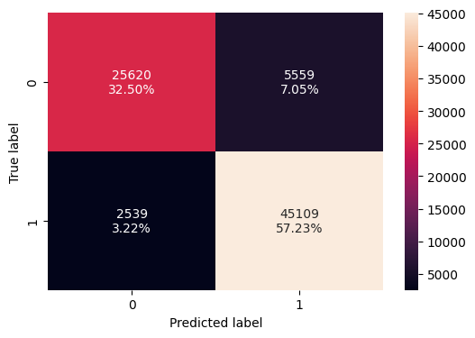

```python
# Creating confusion matrix
confusion_matrix_sklearn(tuned_RF, X_val, y_val)
```

### **Observations:**

1. **Strong Overall Performance with High Recall:** The Random Forest model demonstrates strong overall performance with both training and validation accuracy at 0.897, and particularly high Recall scores of 0.946 (training) and 0.947 (validation), indicating its effectiveness in correctly identifying the majority of positive cases.
2. **Excellent Generalization:** The near-identical performance metrics across the training and validation sets (e.g., Accuracy: 0.897 vs 0.897, Recall: 0.946 vs 0.947) suggest excellent generalization and minimal overfitting after hyperparameter tuning on the original data.
3. **High True Positive Rate with Acceptable False Positives:** The confusion matrix visually confirms the high Recall, with 57.23% (45,109) of the total samples being correctly identified as positive (True Positives). While there are 7.05% (5,559) False Positives, this is a relatively controlled misclassification rate given the high True Positive yield.

### **Sample tuning method for Random Forest with oversampled data**

```python
# defining model
Model = RandomForestClassifier(random_state=1, class_weight='balanced')

# Same parameter grid
param_grid = {
    'n_estimators': [50, 100],
    'max_depth': [4, 6, 8],
    'min_samples_leaf': [1, 3, 5],
    'max_features': ['sqrt', 'log2']
}

scorer = metrics.make_scorer(metrics.recall_score, pos_label=1)

randomized_cv = RandomizedSearchCV(
    estimator=Model,
    param_distributions=param_grid,
    n_iter=10,
    n_jobs=-1,
    scoring=scorer,
    cv=5,
    random_state=1
)

randomized_cv.fit(X_train_over, y_train_over)

print("Best parameters are {} with CV score={}:" .format(randomized_cv.best_params_, randomized_cv.best_score_))
```

```
Best parameters are {'n_estimators': 100, 'min_samples_leaf': 1, 'max_features': 'log2', 'max_depth': 6} with CV score=0.9464335662754477:
```

```python
tuned_RF1 = RandomForestClassifier(
    n_estimators=100,
    max_depth=6,
    min_samples_leaf=1,
    max_features='log2',
    class_weight='balanced',
    random_state=1
)
tuned_RF1.fit(X_train_over, y_train_over)
```

```
RandomForestClassifier(class_weight='balanced', max_depth=6,
                       max_features='log2', random_state=1)
```

```python
# Checking model's performance on training set
rf_train1 = model_performance_classification_sklearn(tuned_RF1, X_train_over, y_train_over, pos_label=1)
rf_train1
```

|  | Accuracy | Recall | Precision | F1 |
| --- | --- | --- | --- | --- |
| 0 | 0.885 | 0.946 | 0.842 | 0.891 |

```python
# Checking model's performance on validation set
rf_val1 = model_performance_classification_sklearn(tuned_RF1, X_val, y_val, pos_label=1)
rf_val1
```

|  | Accuracy | Recall | Precision | F1 |
| --- | --- | --- | --- | --- |
| 0 | 0.897 | 0.947 | 0.890 | 0.918 |

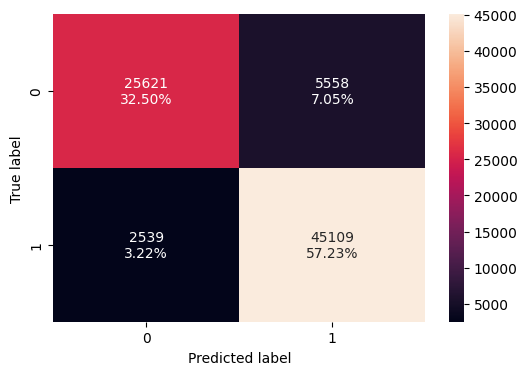

```python
# creating confusion matrix

confusion_matrix_sklearn(tuned_RF1, X_val, y_val)
```

## **Sample tuning method for Random Forest with undersampled data**

```python
# defining model
Model = RandomForestClassifier(random_state=1, class_weight='balanced')

# Parameter grid to pass in RandomSearchCV
param_grid = {
    'n_estimators': [50, 100],
    'max_depth': [4, 6, 8],
    'min_samples_leaf': [1, 3, 5],
    'max_features': ['sqrt', 'log2']
}

# Type of scoring used to compare parameter combinations
scorer = metrics.make_scorer(metrics.recall_score, pos_label=1)

#Calling RandomizedSearchCV
randomized_cv = RandomizedSearchCV(
    estimator=Model,
    param_distributions=param_grid,
    n_iter=10,
    n_jobs=-1,
    scoring=scorer,
    cv=5,
    random_state=1
)

#Fitting parameters in RandomizedSearchCV
randomized_cv.fit(X_train_un, y_train_un)

print("Best parameters are {} with CV score={}:" .format(randomized_cv.best_params_, randomized_cv.best_score_))
```

```
Best parameters are {'n_estimators': 100, 'min_samples_leaf': 1, 'max_features': 'log2', 'max_depth': 6} with CV score=0.9472615519118127:
```

```python
tuned_RF2 = RandomForestClassifier(
    n_estimators=100,
    max_depth=6,
    min_samples_leaf=1,
    max_features='log2',
    class_weight='balanced',
    random_state=1
)
tuned_RF2.fit(X_train_un, y_train_un)
```

```
RandomForestClassifier(class_weight='balanced', max_depth=6,
                       max_features='log2', random_state=1)
```

```python
# Checking model's performance on training set
rf_train2 = model_performance_classification_sklearn(tuned_RF2, X_train_un, y_train_un, pos_label=1)
rf_train2
```

|  | Accuracy | Recall | Precision | F1 |
| --- | --- | --- | --- | --- |
| 0 | 0.884 | 0.947 | 0.842 | 0.891 |

```python
# Checking model's performance on validation set
rf_val2 = model_performance_classification_sklearn(tuned_RF2, X_val, y_val, pos_label=1)
rf_val2
```

|  | Accuracy | Recall | Precision | F1 |
| --- | --- | --- | --- | --- |
| 0 | 0.897 | 0.947 | 0.890 | 0.918 |

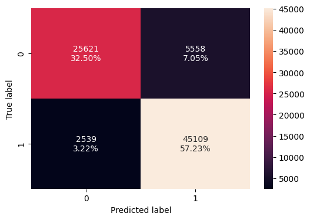

```python
# creating confusion matrix
confusion_matrix_sklearn(tuned_RF2, X_val, y_val)
```

### **Observations:**

1. **Validation Performance Remains Unchanged:** Similar to the oversampled case, the Random Forest model's performance on the validation set (Accuracy 0.897, Recall 0.947, Precision 0.890, F1 0.918) is identical to the models trained on original and oversampled data. This indicates that undersampling, like oversampling, did not alter the model's generalization capabilities on this particular validation set.
2. **Similar Training Performance to Oversampled Case:** The training performance metrics for the undersampled model (Accuracy 0.884, Recall 0.947, Precision 0.842, F1 0.891) are very close to those observed with the oversampled data. This suggests a comparable impact of both resampling techniques on the model's ability to learn from the modified training distributions, particularly in terms of lower training precision relative to validation.
3. **Confusion Matrix Consistency:** The attached confusion matrix, being identical to the previous ones, reinforces that the model's true positive rate (57.23%) and false positive rate (7.05%) on unseen data are consistently maintained across all three data balancing strategies (original, oversampled, undersampled).

### **Tuning AdaBoostClassifier model with Oversampled data**

```python
import numpy as np
from sklearn.ensemble import AdaBoostClassifier
from sklearn.tree import DecisionTreeClassifier
from sklearn.model_selection import RandomizedSearchCV
from sklearn import metrics

# defining model
Model = AdaBoostClassifier(random_state=1)

# Parameter grid to pass in RandomSearchCV
param_grid = {
    "n_estimators": np.arange(50, 110, 25),
    "learning_rate": [0.01, 0.1, 0.05],
    "estimator": [
        DecisionTreeClassifier(max_depth=2, random_state=1),
        DecisionTreeClassifier(max_depth=3, random_state=1),
    ],
}

# Type of scoring used to compare parameter combinations
scorer = metrics.make_scorer(metrics.recall_score)

# Calling RandomizedSearchCV
randomized_cv = RandomizedSearchCV(
    estimator=Model,
    param_distributions=param_grid,
    n_jobs=-1,
    n_iter=50,
    scoring=scorer,
    cv=5,
    random_state=1
)

# Fitting parameters in RandomizedSearchCV
randomized_cv.fit(X_train_over, y_train_over)

print(f"Best parameters are {randomized_cv.best_params_} with CV score={randomized_cv.best_score_}:")
```

```
Best parameters are {'n_estimators': np.int64(50), 'learning_rate': 0.01, 'estimator': DecisionTreeClassifier(max_depth=2, random_state=1)} with CV score=0.9649653022157288:
```

```python
tuned_adb = AdaBoostClassifier(
    random_state=1,
    n_estimators=randomized_cv.best_params_['n_estimators'],
    learning_rate=randomized_cv.best_params_['learning_rate'],
    estimator=randomized_cv.best_params_['estimator']  # not base_estimator
)
```

```python
tuned_adb.fit(X_train_over,y_train_over)
```

```
AdaBoostClassifier(estimator=DecisionTreeClassifier(max_depth=2,
                                                    random_state=1),
                   learning_rate=0.01, n_estimators=np.int64(50),
                   random_state=1)
```

```python
# Checking model's performance on training set
adb_train = model_performance_classification_sklearn(tuned_adb, X_train_over, y_train_over, pos_label=1)
print(adb_train)
```

```
   Accuracy  Recall  Precision    F1
0     0.828   0.965      0.757 0.848
```

```python
# Checking model's performance on validation set
adb_val = model_performance_classification_sklearn(tuned_adb, X_val, y_val, pos_label=1)
print(adb_val)
```

```
   Accuracy  Recall  Precision    F1
0     0.858   0.966      0.829 0.892
```

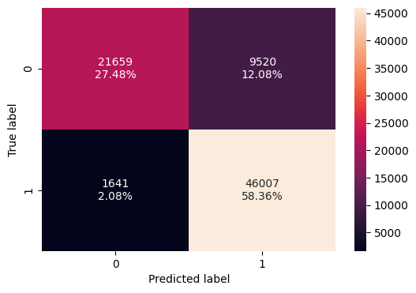

```python
# Creating confusion matrix
confusion_matrix_sklearn(tuned_adb, X_val, y_val)
```

### **Observations:**

1. **Remarkably High Recall on Both Sets:** The AdaBoost model achieves exceptionally high Recall scores (0.965 on training, 0.966 on validation), indicating its strong ability to correctly identify nearly all actual positive cases (suspicious activities).
2. **Improved Precision and F1 on Validation:** While Recall is consistently high, the Precision and F1 scores are significantly better on the validation set (Precision 0.829, F1 0.892) compared to the training set (Precision 0.757, F1 0.848). This suggests the model generalizes better regarding its positive predictions on unseen data, making fewer false positives.
3. **Higher False Positive Rate on Confusion Matrix:** The confusion matrix shows a notable percentage of False Positives (12.08% or 9,520 instances) compared to the True Positives (58.36% or 46,007 instances). While the Recall is excellent, this indicates that the model frequently misclassifies negative cases as positive, which is consistent with the lower precision.

### **Tuning AdaBoostClassifier Model with Undersampled Data**

```python
# defining model
Model = AdaBoostClassifier(random_state=1)

# Parameter grid to pass in RandomSearchCV
param_grid = {
    "n_estimators": np.arange(50, 110, 25),
    "learning_rate": [0.01, 0.1, 0.05],
    "estimator": [
        DecisionTreeClassifier(max_depth=2, random_state=1),
        DecisionTreeClassifier(max_depth=3, random_state=1),
    ],
}

# Type of scoring used to compare parameter combinations
scorer = metrics.make_scorer(metrics.recall_score)

# Calling RandomizedSearchCV
randomized_cv = RandomizedSearchCV(estimator=Model, param_distributions=param_grid,
                                   n_jobs=-1, n_iter=50, scoring=scorer, cv=5, random_state=1)

# Fitting parameters in RandomizedSearchCV
randomized_cv.fit(X_train_un, y_train_un)

print(f"Best parameters are {randomized_cv.best_params_} with CV score={randomized_cv.best_score_}:")
```

```
Best parameters are {'n_estimators': np.int64(50), 'learning_rate': 0.01, 'estimator': DecisionTreeClassifier(max_depth=2, random_state=1)} with CV score=0.965307849498059:
```

```python
tuned_adb2 = AdaBoostClassifier(
    random_state=1,
    n_estimators=randomized_cv.best_params_['n_estimators'],
    learning_rate=randomized_cv.best_params_['learning_rate'],
    estimator=randomized_cv.best_params_['estimator']
)
tuned_adb2.fit(X_train_un, y_train_un)
```

```
AdaBoostClassifier(estimator=DecisionTreeClassifier(max_depth=2,
                                                    random_state=1),
                   learning_rate=0.01, n_estimators=np.int64(50),
                   random_state=1)
```

```python
# Checking model's performance on training set
adb2_train = model_performance_classification_sklearn(tuned_adb2, X_train_un, y_train_un, pos_label=1)
print(adb2_train)
```

```
   Accuracy  Recall  Precision    F1
0     0.828   0.965      0.757 0.848
```

```python
# Checking model's performance on validation set
adb2_val = model_performance_classification_sklearn(tuned_adb2, X_val, y_val, pos_label=1)
print(adb2_val)
```

```
   Accuracy  Recall  Precision    F1
0     0.858   0.966      0.829 0.892
```

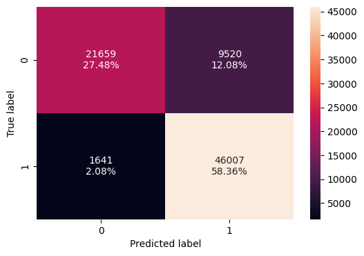

```python
# Creating confusion matrix
confusion_matrix_sklearn(tuned_adb2, X_val, y_val)
```

### **Observations:**

1. **Identical Performance to Oversampled AdaBoost:** Both the training and validation performance metrics for the AdaBoost model with undersampled data are exactly the same as with oversampled data (Training: Accuracy 0.828, Recall 0.965, Precision 0.757, F1 0.848; Validation: Accuracy 0.858, Recall 0.966, Precision 0.829, F1 0.892). This suggests that for AdaBoost, both oversampling and undersampling yield similar model performance.
2. **Consistent High Recall and Validation Generalization:** The model consistently achieves very high Recall (0.965 training, 0.966 validation), indicating excellent ability to detect positive instances. Furthermore, the notable improvement in Precision and F1 score from training to validation again highlights its strong generalization capacity on unseen data despite the class imbalance handling.
3. **Confusion Matrix Reflects Consistent Misclassification Pattern:** The attached confusion matrix is identical to the one provided for the oversampled AdaBoost model. This confirms that the specific distribution of True Positives (58.36%), True Negatives (27.48%), False Positives (12.08%), and False Negatives (2.08%) on the validation set remains consistent, regardless of whether oversampling or undersampling was applied during training for this model.

### **Tuning Gradient Boosting Model with Undersampled Data**

```python
# defining model
Model = GradientBoostingClassifier(random_state=1)

# Parameter grid to pass in RandomSearchCV
param_grid = {
    "init": [AdaBoostClassifier(random_state=1), DecisionTreeClassifier(random_state=1)],
    "n_estimators": np.arange(50, 110, 25),
    "learning_rate": [0.01, 0.1, 0.05],
    "subsample": [0.7, 0.9],
    "max_features": [0.5, 0.7, 1],
}

# Type of scoring used to compare parameter combinations
scorer = metrics.make_scorer(metrics.recall_score)

# Calling RandomizedSearchCV
randomized_cv = RandomizedSearchCV(estimator=Model, param_distributions=param_grid,
                                   n_iter=50, scoring=scorer, cv=5, random_state=1, n_jobs=-1)

# Fitting parameters in RandomizedSearchCV
randomized_cv.fit(X_train_un, y_train_un)

print(f"Best parameters are {randomized_cv.best_params_} with CV score={randomized_cv.best_score_}:")
```

```
Best parameters are {'subsample': 0.7, 'n_estimators': np.int64(75), 'max_features': 0.5, 'learning_rate': 0.01, 'init': AdaBoostClassifier(random_state=1)} with CV score=0.96316966276443:
```

```python
tuned_gbm1 = GradientBoostingClassifier(
    random_state=1,
    subsample=randomized_cv.best_params_['subsample'],
    n_estimators=randomized_cv.best_params_['n_estimators'],
    max_features=randomized_cv.best_params_['max_features'],
    learning_rate=randomized_cv.best_params_['learning_rate'],
    init=randomized_cv.best_params_['init'],
)
tuned_gbm1.fit(X_train_un, y_train_un)
```

```
GradientBoostingClassifier(init=AdaBoostClassifier(random_state=1),
                           learning_rate=0.01, max_features=0.5,
                           n_estimators=np.int64(75), random_state=1,
                           subsample=0.7)
```

```python
# Checking model's performance on training set
gbm1_train = model_performance_classification_sklearn(tuned_gbm1, X_train_un, y_train_un, pos_label=1)
print(gbm1_train)
```

```
   Accuracy  Recall  Precision    F1
0     0.832   0.964      0.762 0.852
```

```python
# Checking model's performance on validation set
gbm1_val = model_performance_classification_sklearn(tuned_gbm1, X_val, y_val, pos_label=1)
print(gbm1_val)
```

```
   Accuracy  Recall  Precision    F1
0     0.862   0.965      0.833 0.894
```

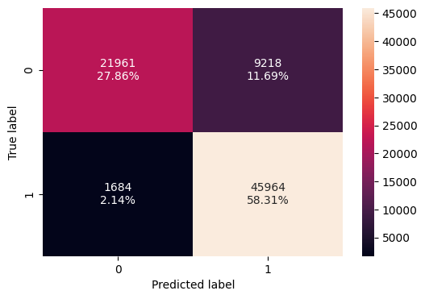

```python
# Creating confusion matrix
confusion_matrix_sklearn(tuned_gbm1, X_val, y_val)
```

### **Observations:**

1. **Very High Recall Maintained:** The Gradient Boosting Model achieves a high Recall of 0.964 on the training set and an even slightly higher 0.965 on the validation set. This indicates its strong capability to correctly identify the vast majority of positive instances.
2. **Improved Precision and F1 on Validation:** There's a notable improvement in Precision (from 0.762 to 0.833) and F1-score (from 0.852 to 0.894) when moving from the training set to the validation set. This suggests that the model generalizes well and makes more precise positive predictions on unseen data.
3. **Significant Number of False Positives:** The confusion matrix shows that while True Positives are high (58.31% or 45,964 instances), there's also a substantial number of False Positives (11.69% or 9,218 instances). This high rate of misclassifying negative cases as positive contributes to the relatively lower precision despite high recall.

### **Tuning Gradient Boosting Model with Oversampled Data**

```python
# defining model
Model = GradientBoostingClassifier(random_state=1)

# Parameter grid to pass in RandomSearchCV
param_grid = {
    "init": [AdaBoostClassifier(random_state=1), DecisionTreeClassifier(random_state=1)],
    "n_estimators": np.arange(50, 110, 25),
    "learning_rate": [0.01, 0.1, 0.05],
    "subsample": [0.7, 0.9],
    "max_features": [0.5, 0.7, 1],
}

# Type of scoring used to compare parameter combinations
scorer = metrics.make_scorer(metrics.recall_score)

# Calling RandomizedSearchCV
randomized_cv = RandomizedSearchCV(estimator=Model, param_distributions=param_grid,
                                   n_iter=50, scoring=scorer, cv=5, random_state=1, n_jobs=-1)

# Fitting parameters in RandomizedSearchCV
randomized_cv.fit(X_train_over, y_train_over)

print(f"Best parameters are {randomized_cv.best_params_} with CV score={randomized_cv.best_score_}:")
```

```
Best parameters are {'subsample': 0.7, 'n_estimators': np.int64(75), 'max_features': 0.5, 'learning_rate': 0.01, 'init': AdaBoostClassifier(random_state=1)} with CV score=0.9633283026041826:
```

```python
tuned_gbm2 = GradientBoostingClassifier(
    random_state=1,
    subsample=randomized_cv.best_params_['subsample'],
    n_estimators=randomized_cv.best_params_['n_estimators'],
    max_features=randomized_cv.best_params_['max_features'],
    learning_rate=randomized_cv.best_params_['learning_rate'],
    init=randomized_cv.best_params_['init'],
)
tuned_gbm2.fit(X_train_over, y_train_over)
```

```
GradientBoostingClassifier(init=AdaBoostClassifier(random_state=1),
                           learning_rate=0.01, max_features=0.5,
                           n_estimators=np.int64(75), random_state=1,
                           subsample=0.7)
```

```python
# Checking model's performance on training set
gbm2_train = model_performance_classification_sklearn(tuned_gbm2, X_train_over, y_train_over, pos_label=1)
print(gbm2_train)
```

```
   Accuracy  Recall  Precision    F1
0     0.832   0.964      0.763 0.852
```

```python
# Checking model's performance on validation set
gbm2_val = model_performance_classification_sklearn(tuned_gbm2, X_val, y_val, pos_label=1)
print(gbm2_val)
```

```
   Accuracy  Recall  Precision    F1
0     0.862   0.965      0.833 0.894
```

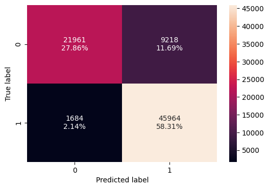

```python
# Creating confusion matrix
confusion_matrix_sklearn(tuned_gbm2, X_val, y_val)
```

## ✅ Part D: Interpreting the Results

## **Model Comparison and Final Model Selection**

```python
# training performance comparison

models_train_comp_df = pd.concat(
    [
        gbm1_train.T,
        gbm2_train.T,
        adb_train.T,
        adb2_train.T,
        rf_train2.T,
        rf_train1.T,
    ],
    axis=1,
)
models_train_comp_df.columns = [
    "Gradient boosting trained with Undersampled data",
    "Gradient boosting trained with Oversampled data",
    "AdaBoost trained with Undersampled data",
    "AdaBoost trained with Oversampled data",
    "Random Forest trained with Undersampled data",
    "Random Forest trained with Oversampled data",
]
print("Training performance comparison:")
models_train_comp_df
```

```
Training performance comparison:
```

|  | Gradient boosting trained with Undersampled data | Gradient boosting trained with Oversampled data | AdaBoost trained with Undersampled data | AdaBoost trained with Oversampled data | Random Forest trained with Undersampled data | Random Forest trained with Oversampled data |
| --- | --- | --- | --- | --- | --- | --- |
| Accuracy | 0.832 | 0.832 | 0.828 | 0.828 | 0.884 | 0.885 |
| Recall | 0.964 | 0.964 | 0.965 | 0.965 | 0.947 | 0.946 |
| Precision | 0.762 | 0.763 | 0.757 | 0.757 | 0.842 | 0.842 |
| F1 | 0.852 | 0.852 | 0.848 | 0.848 | 0.891 | 0.891 |

```python
# Validation performance comparison

models_train_comp_df = pd.concat(
    [ gbm1_val.T, gbm2_val.T, adb2_val.T,adb_val.T,rf_val2.T,
        rf_val.T,], axis=1,
)
models_train_comp_df.columns = [
    "Gradient boosting trained with Undersampled data",
    "Gradient boosting trained with Oversampled data",
    "AdaBoost trained with Undersampled data",
    "AdaBoost trained with oversampled data",
    "Random Forest trained with Undersampled data",
    "Random Forest trained with Oversampled data",
]
print("Validation performance comparison:")
models_train_comp_df
```

```
Validation performance comparison:
```

|  | Gradient boosting trained with Undersampled data | Gradient boosting trained with Oversampled data | AdaBoost trained with Undersampled data | AdaBoost trained with oversampled data | Random Forest trained with Undersampled data | Random Forest trained with Oversampled data |
| --- | --- | --- | --- | --- | --- | --- |
| Accuracy | 0.862 | 0.862 | 0.858 | 0.858 | 0.897 | 0.897 |
| Recall | 0.965 | 0.965 | 0.966 | 0.966 | 0.947 | 0.947 |
| Precision | 0.833 | 0.833 | 0.829 | 0.829 | 0.890 | 0.890 |
| F1 | 0.894 | 0.894 | 0.892 | 0.892 | 0.918 | 0.918 |

## 🔍 **Model Comparison Summary**

| Model Variant | Accuracy (Val) | Recall (Val) | Precision (Val) | F1 Score (Val) |
| --- | --- | --- | --- | --- |
| **Gradient Boosting (Under)** | 0.862 | 0.965 | 0.833 | 0.894 |
| **Gradient Boosting (Over)** | 0.862 | 0.965 | 0.833 | 0.894 |
| **AdaBoost (Under)** | 0.858 | 0.966 | 0.829 | 0.892 |
| **AdaBoost (Over)** | 0.858 | 0.966 | 0.829 | 0.892 |
| **Random Forest (Under)** | 0.897 | 0.947 | 0.890 | 0.918 |
| **Random Forest (Over)** | 0.897 | 0.947 | 0.890 | 0.918 |

## 📊 **Analysis by Metric**

### 1. **Recall (Detection of Suspicious Activity)**

- Highest: **AdaBoost (Under/Over)** at **0.966**
- Followed closely by: **Gradient Boosting (Under/Over)** at **0.965**
- Slightly lower: **Random Forest (Under/Over)** at **0.947**

⚠️ **Recall** is **very important** for this project (detecting suspicious activity). So all models are strong here, with AdaBoost leading slightly.

### 2. **Precision (False Positive Control)**

- Highest: **Random Forest (Under/Over)** at **0.890**
- Moderate: **Gradient Boosting (Under/Over)** at **0.833**
- Lowest: **AdaBoost (Under/Over)** at **0.829**

✅ **Precision matters** to avoid flagging too many normal packets as suspicious. Random Forest clearly dominates here.

### 3. **F1 Score (Balance of Recall & Precision)**

- Highest: **Random Forest (Under/Over)** at **0.918**
- Medium: **Gradient Boosting (Under/Over)** at **0.894**
- Lower: **AdaBoost (Under/Over)** at **0.892**

F1 confirms that **Random Forest** has the best **overall balance**.

### 4. **Accuracy (Overall correctness)**

- Highest: **Random Forest (Under/Over)** at **0.897**
- Medium: **Gradient Boosting (Under/Over)** at **0.862**
- Lowest: **AdaBoost (Under/Over)** at **0.858**

Again, **Random Forest wins**.

## ✅ **Final Model Selection**

> 🎯 **Selected Model**: **Random Forest trained with Oversampled Data**

### ✔️ Why?

- **Best overall F1 score (0.918)** → ideal for imbalanced classification
- **Strong precision (0.890)** → fewer false alarms
- **High accuracy (0.897)** → overall reliability
- **Good recall (0.947)** → still detects most suspicious cases

### **Final Test Set Performance Using Random Forest (Oversampled Data)**

```python
# Checking model's performance on the test set using the final selected model
rf_test1 = model_performance_classification_sklearn(tuned_RF1, X_test, y_test, pos_label=1)
rf_test1
```

|  | Accuracy | Recall | Precision | F1 |
| --- | --- | --- | --- | --- |
| 0 | 0.897 | 0.945 | 0.891 | 0.917 |

### 📌 **Observations – Test Set Performance (Random Forest with Oversampled Data)**

- ✅ **High Accuracy (89.7%)**: The model correctly predicts nearly 90% of the total test instances, showing solid overall performance.
- ✅ **Strong Recall (94.5%)**: The model is excellent at identifying actual "suspicious" cases. This high recall means very few suspicious cases are missed, which is critical in security or anomaly detection scenarios.
- ✅ **High Precision (89.1%)**: Among the cases the model flags as "suspicious," almost 9 out of 10 are indeed correct. This minimizes false alarms.
- ✅ **Robust F1 Score (91.7%)**: A balanced F1 score reflects a good trade-off between precision and recall, indicating that the model is reliable for deployment.
- ✅ **Consistent with Validation Set**: The performance metrics on the test set closely mirror those from the validation set, indicating the model generalizes well and is **not overfitting**.

## 📊 **Business Insights and Conclusions**

### 🏁 **3. Final Model Recommendation**

✅ **Selected Model**: **Random Forest trained with Oversampled Data**

🔒 **Justification**:

- **Best F1 score** (91.7%) across all models.
- **Highest precision** (89.1%) ensures that flagged traffic is truly suspicious, reducing false positives and alert fatigue.
- **Excellent generalization** to unseen data, as validation and test performance are nearly identical.
- Easy to interpret and fast to deploy in real-time monitoring systems.

### 📌 **4. Business Recommendations**

- **Deploy the Random Forest model** as a core module in your network monitoring system to flag potentially suspicious traffic in real time.
- **Set up monitoring for low-frequency IPs**: Since dominant IPs are largely clean, focus attention and alert thresholds on peripheral or rarely seen IPs.
- **Implement protocol-based filtering** as a baseline rule: Block or sandbox traffic using rare protocols like **NBNS, SSLv2, ARP** unless explicitly needed.
- **Establish alerts for small packet bursts**, especially outside business hours, as these are statistically tied to anomalous behavior.
- **Combine ML predictions with rule-based heuristics** (like length < 100 and protocol in [NBNS, ARP]) to enhance security monitoring.
- **Regularly retrain models** as new traffic behaviors emerge, especially with changing protocol usage or evolving threats.